# Previsão de Preços de Uva com o Ecossistema Nixtla

Referencial metodológico e protótipo (Arra 15 e BRS Vitória)

Autor

João Ricardo F. de Lima

Data de Publicação

17 de novembro de 2026

# Parte I — Referencial Metodológico

> Esta primeira parte é um material de apoio sobre **modelos de previsão de preços**, escrito para servir de referência didática (os fundamentos gerais — por que preços são difíceis de prever, por que frutas ainda mais — já estão documentados na versão para manga e não são repetidos aqui). A segunda parte aplica tudo isso, na prática, ao preço da uva com o ecossistema **Nixtla**.

## 3. Os canais que movem o preço da uva no Vale do São Francisco

> **Nota de método.** Ao contrário da manga — onde os mecanismos abaixo já tinham sido validados no rolling-origin antes deste documento — para a uva **nenhum destes canais foi testado no rolling-origin ainda**. O que segue são **hipóteses de mecanismo**, acompanhadas, quando existem, de evidência exploratória (climatologia, correlações simples) que serve para *orientar o sinal esperado* — nunca como validação. São candidatos a entrar na fila de exógenas (§12), e cada um só fica se pagar aluguel no rolling-origin (§8 em diante). O primeiro teste real já saiu diferente do esperado: o Fourier (sazonalidade determinística) foi **descartado** (§8.2) porque a uva do VSF, ao contrário da manga, não tem calendário biológico fixo — a produção é **programada por poda** (2 ciclos de colheita por ano, decisão do produtor), não disparada por floração natural em época certa. Isso muda onde faz sentido procurar mecanismo: não em defasagens biológicas fixas (tipo “16 semanas da floração”), mas em janelas **curtas e próximas da colheita**, e em canais **não sazonais** (câmbio, ENSO).

### 3.1 Clima local: a chuva na colheita

Na uva do VSF há um mecanismo climático dominante, e ele é **estreito no tempo**: a chuva só importa **na colheita ou perto dela**. Fora dessa janela, o parreiral irrigado é indiferente à precipitação — a água vem da irrigação, não do céu. Mas chover sobre cacho maduro ou quase maduro é grave: a baga absorve água, incha e **racha**; a lesão abre porta para **podridão**, que progride no cacho e na caixa. Perde-se quantidade *e* qualidade.

**Por que o sinal esperado é negativo (ao contrário da manga).** Na manga, a chuva atingia a **floração**: menos pegamento → menos fruta meses depois → preço **sobe**. Na uva, a chuva atinge o **produto pronto**. E uva é perecível sem estoque: a fruta danificada **não pode ser retida** à espera de mercado melhor — ela desce de categoria e é vendida assim mesmo. O canal dominante deixa de ser escassez e passa a ser **deterioração da qualidade média ofertada**, que empurra o preço **para baixo**. Mesmo fenômeno físico, sinal oposto ao da manga, porque o momento do ciclo é outro.

**Colhe-se o ano todo, mas com pico em outubro–novembro.** A poda programada espalha a colheita pelo calendário, com concentração em out/nov. E é justamente aí que o VSF sai da estação seca: nas séries NASA POWER (2012–2026), a chuva semanal média sobe de **0,8 mm em setembro** e **2,5 mm em outubro** para **8,1 mm em novembro** e **10,8 mm em dezembro**. O pico de colheita coincide com a virada para o período chuvoso — a exposição é estrutural, não acidental.

**O que torna isso um candidato preditivo é a variabilidade interanual.** O acumulado de outubro+novembro no VSF variou, nesse período, de **6 mm (2015) a 130 mm (2020)** — uma razão de mais de 20×, com desvio-padrão (40 mm) quase do tamanho da média (46 mm). É exatamente o tipo de sinal que um termo determinístico **não** captura: o calendário do risco é fixo, mas a **intensidade** muda radicalmente de ano para ano. Isso reconcilia este candidato com a rejeição do Fourier (§8.2) — não estamos reintroduzindo sazonalidade média, e sim o desvio anual dentro de uma janela crítica.

**Evidência exploratória (fraca, mas do sinal esperado).** Correlacionando o acumulado out+nov com o preço real médio de out–dez do mesmo ano ($n=9$ safras): $r=-0{,}61$ na BRS Vitória ($p=0{,}08$) e $r=-0{,}33$ na Arra 15 ($p=0{,}38$). O sinal é negativo nas duas, como o mecanismo de qualidade prevê — mas **nada aqui é conclusivo**: com nove observações o poder é ínfimo; na Arra o Spearman colapsa para $+0{,}02$, revelando que a correlação de Pearson é carregada pelos anos extremos; e os anos mais chuvosos (2020–2021) coincidem com o choque de demanda da COVID, um confundidor evidente. Vale como *orientação de sinal*, não como resultado.

**A restrição séria: o lag do mecanismo é mais curto que o horizonte.** O dano é contemporâneo — chove na semana $t$ e o estrago aparece no preço de $t$ a $t+2$. Como não conhecemos a chuva de seis semanas à frente, a variável **não é utilizável em $h=6$ na forma direta**. Três saídas testáveis:

1. **Persistência do choque.** Se a chuva do pico de colheita destrói lotes, o efeito sobre o mercado pode durar semanas — então chuva acumulada em lags 4–6 pode carregar sinal mesmo com o dano já consumado.
2. **Modelo de horizonte curto.** Uma especificação separada para $h\le4$, em que a chuva recente é observável e o mecanismo está no alcance. Faz sentido operacional: o boletim é semanal, e a decisão de curto prazo é a mais frequente.
3. **Previsão meteorológica como insumo.** Substituir a chuva observada por previsão de precipitação no horizonte — muda a natureza do dado (e traz o erro do modelo meteorológico junto), mas é o único caminho para usar o mecanismo em sua forma contemporânea.

**Calor na maturação (secundário).** Temperatura alta na fase final afeta açúcar e firmeza; o efeito sobre preço é ambíguo *a priori* (depende de estar dentro ou fora do ótimo da variedade). Candidata: `hot_days_35`, com lag a determinar. Sem hipótese direcional forte, entra depois da chuva na fila.

Em todos os casos vale a regra da §8.2: **o lag é para descobrir, não para herdar** — nenhuma defasagem da manga se transfere.

### 3.2 Canal de exportação e câmbio

- **Câmbio.** Real desvalorizado → exportar é mais atrativo → menos uva no mercado interno → preço sobe. Mecanismo esperado mais forte na **Arra 15** (variedade historicamente mais orientada a exportação) do que na Vitória (mercado interno).
- **Peru como concorrente/parâmetro de calendário.** O Peru é o **maior exportador mundial de uva de mesa** — Piura e Lambayeque (já monitorados em `gerar_clima.py`, junto com Casma e Equador) pesam nesse canal ainda mais do que pesavam para a manga. A hipótese, por analogia ao mecanismo ENSO usado na manga (Ubilava (2018)), é que anomalias climáticas nessas regiões desloquem a safra peruana e, por essa via, afetem a janela de exportação brasileira — mas o calendário de colheita da uva peruana e a defasagem correta **ainda não foram mapeados** para este projeto (diferente da manga, onde o lag de ~6 meses via Niño 1+2/3.4 já estava estabelecido).
- Câmbio e Niño (1+2 e 3.4) são as **próximas exógenas da fila** (§12), a testar sem Fourier, cada uma isoladamente contra o piso univariado.

### 3.3 Competição doméstica

Quatro polos concentram a produção brasileira de **uva de mesa** e disputam o consumidor interno:

| Polo | UF | Regime de produção |
| --- | --- | --- |
| **Vale do São Francisco** (Petrolina/Juazeiro) | PE/BA | Irrigado, semiárido — **produção programada por poda**, 2 ciclos/ano |
| **Pirapora** | MG | Irrigado, norte de Minas — também com poda programada |
| **Jales** | SP | Noroeste paulista — ciclo mais preso à estação natural |
| **Marialva** | PR | Norte do Paraná — ciclo subtropical, colheita de verão |

A distinção que importa para a modelagem **não é geográfica, é de regime**: VSF e Pirapora podem *escolher* quando colher (a poda define a data); Jales e Marialva têm janela mais amarrada ao ciclo natural da videira. Isso divide os concorrentes em dois grupos com implicações preditivas diferentes.

**Por que a competição não aparece como sazonalidade.** Se a oferta do Sul/ Sudeste chegasse sempre na mesma época *e* com peso relevante, os termos de Fourier teriam capturado esse efeito — e não capturaram: o Fourier foi **rejeitado** em três famílias de modelo (§8.2). Restam duas leituras, ambas compatíveis com o achado: (i) o efeito médio de calendário é fraco no preço do VSF; ou (ii) o *timing* é estável mas a **intensidade varia ano a ano** (área colhida, quebra por clima, volume efetivo) — e uma curva anual determinística, por construção, não representa variação de intensidade.

A segunda leitura é a que abre espaço preditivo, e ela aponta para o mesmo tipo de variável que usamos no canal externo: **anomalia**, não nível. O sinal candidato é o desvio do clima de cada polo concorrente em relação à sua própria normal — um ano de quebra em Marialva ou Jales desloca oferta para o mercado nacional em magnitude atípica, e é essa atipicidade (não o calendário médio) que teria conteúdo além do que o preço passado já traz.

**Por que clima e não preço regional.** Usar o preço de outro polo como regressor é **endógeno**: os preços das regiões são determinados simultaneamente no mesmo mercado nacional, e a regressão captaria correlação contemporânea sem direção causal. O clima regional é **predeterminado** (não responde ao preço da uva no VSF) e, portanto, admissível como preditor.

**Estado dos dados — o que falta.** O `gerar_clima.py` herdado da manga cobre polos que **não** correspondem a estas regiões: Livramento/BA, Jaíba/MG e Monte Alto/SP são polos de manga. Só o VSF (Petrolina) coincide. Para testar este canal é preciso primeiro adicionar as coordenadas de **Pirapora/MG**, **Jales/SP** e **Marialva/PR** ao gerador e baixar as séries NASA POWER correspondentes. Enquanto isso não for feito, o canal permanece **não testado** — não entra na fila de exógenas (§12) por falta de dado, não por decisão metodológica.

## 4. Modelos de previsão

### 4.1 ARIMA e a sazonalidade por Fourier

Um **ARIMA(p,d,q)** (Box et al. 2015) escreve-se, com $L$ o operador de defasagem,
$$\phi(L)\,(1-L)^d y_t = \theta(L)\,\varepsilon_t,$$
$$\phi(L)=1-\phi_1 L-\dots-\phi_p L^p,\qquad \theta(L)=1+\theta_1 L+\dots+\theta_q L^q.$$

Com regressores externos, temos a **regressão com erros ARIMA** (ARIMAX):
$$y_t = \boldsymbol{\beta}'\mathbf{x}_t + n_t, \qquad \phi(L)(1-L)^d n_t = \theta(L)\varepsilon_t .$$

**Sazonalidade.** Em dados semanais o período é $m=52$. Um SARIMA sazonal clássico $(P,D,Q)_{52}$ é problemático (a diferenciação sazonal descarta um ano de dados; um termo no lag 52 não descreve uma curva anual suave; o espaço de estados fica enorme). A alternativa recomendada é a **regressão harmônica dinâmica** (Hyndman e Athanasopoulos 2021): sazonalidade determinística por **termos de Fourier** como exógenas,
$$s_t=\sum_{k=1}^{K}\Big[\alpha_k\sin\!\Big(\tfrac{2\pi k\, d_t}{365.25}\Big)+\beta_k\cos\!\Big(\tfrac{2\pi k\, d_t}{365.25}\Big)\Big],$$
com $d_t$ = dia do ano. Poucos harmônicos ($K=1$ ou $2$) costumam bastar.

### 4.2 Modelos de Machine Learning: gradient boosting e XGBoost

Um modelo de **gradient boosting** (Friedman 2001) aprende $f$ de forma aditiva, somando $M$ árvores de decisão simples (*weak learners*) treinadas em sequência, cada uma corrigindo o erro que sobrou da anterior:
$$\hat{y}_i^{(0)} = 0, \qquad \hat{y}_i^{(m)} = \hat{y}_i^{(m-1)} + \eta\, f_m(\mathbf{x}_i), \qquad m = 1,\dots,M,$$
onde $\eta\in(0,1]$ é a **taxa de aprendizagem** (*learning rate*/*shrinkage*): passos pequenos exigem mais árvores, mas generalizam melhor (menos overfitting).

O **XGBoost** (Chen e Guestrin 2016) formaliza o ajuste de cada árvore $f_m$ como a minimização de uma função objetivo **regularizada**,
$$\mathcal{L}^{(m)} = \sum_{i=1}^n \ell\big(y_i,\, \hat{y}_i^{(m-1)} + f_m(\mathbf{x}_i)\big) + \Omega(f_m), \qquad
\Omega(f) = \gamma T + \tfrac{1}{2}\lambda \sum_{j=1}^{T} w_j^2,$$
com $T$ o número de folhas da árvore, $w_j$ o valor previsto em cada folha, e $\gamma,\lambda$ penalizando árvores grandes e pesos extremos — o análogo, em ML, à parcimônia que o AIC impõe no ARIMA.

Para otimizar rápido qualquer $\ell$ diferenciável, o XGBoost expande $\mathcal{L}^{(m)}$ em **série de Taylor de 2ª ordem** ao redor de $\hat y^{(m-1)}$:
$$\mathcal{L}^{(m)} \approx \sum_{i=1}^n \Big[g_i\, f_m(\mathbf{x}_i) + \tfrac12 h_i\, f_m(\mathbf{x}_i)^2\Big] + \Omega(f_m),
\qquad g_i = \partial_{\hat y}\ell(y_i,\hat y_i^{(m-1)}),\;\; h_i = \partial^2_{\hat y}\ell(y_i,\hat y_i^{(m-1)}),$$
gradiente e hessiana da perda ($\ell$) — daí o apelido de *Newton boosting*. Para erro quadrático, $g_i=\hat y_i^{(m-1)}-y_i$ e $h_i=1$, recuperando o gradient boosting clássico como caso particular.

Fixada a estrutura da árvore, com $I_j$ as observações que caem na folha $j$, o peso ótimo e o objetivo mínimo têm **forma fechada**:
$$w_j^\ast = -\frac{\sum_{i\in I_j} g_i}{\sum_{i\in I_j} h_i + \lambda}, \qquad
\mathcal{L}^\ast = -\tfrac12\sum_{j=1}^{T} \frac{\big(\sum_{i\in I_j}g_i\big)^2}{\sum_{i\in I_j}h_i+\lambda} + \gamma T.$$
Essa mesma expressão decide **onde dividir** cada nó: o algoritmo escolhe a variável e o limiar que maximizam o **ganho** — a redução de $\mathcal{L}^\ast$ ao separar o nó pai ($I = I_L \cup I_R$) em dois filhos,
$$\text{Gain} = \tfrac12\left[\frac{(\sum_{I_L}g_i)^2}{\sum_{I_L}h_i+\lambda} + \frac{(\sum_{I_R}g_i)^2}{\sum_{I_R}h_i+\lambda} - \frac{(\sum_{I}g_i)^2}{\sum_{I}h_i+\lambda}\right] - \gamma.$$
Um split só é aceito se o ganho superar $\gamma$ — é assim que o XGBoost **poda** divisões que não compensam a complexidade adicionada.

Na prática (ver §8): $M=200$ árvores (`n_estimators`), profundidade máxima 3 (`max_depth` — limita quantas variáveis interagem por árvore), $\eta=0.05$ (`learning_rate`), e como atributos as defasagens $y_{t-1}, y_{t-2}, y_{t-4}, y_{t-52}$ mais as exógenas (Fourier, Niño, câmbio) candidatas a cada split. Diferente do ARIMA(X), árvores **não extrapolam** tendência ou sazonalidade fora do range visto em treino (preveem médias dentro de partições) — por isso os termos de Fourier (determinísticos, logo sempre “conhecidos”) são o que dá sazonalidade ao XGBoost, e a previsão multi-passo é **recursiva**: cada horizonte usa as previsões dos horizontes anteriores como parte dos lags. Isso também explica por que XGBoost e AutoARIMA erram de formas diferentes — e por que a combinação dos dois (§4.4) tende a reduzir o erro combinado.

### 4.3 Redes neurais para séries temporais: NHITS

O **NHITS** (*Neural Hierarchical Interpolation for Time Series*) (Challu et al. 2023) é o sucessor do N-BEATS e, ao contrário do que o rótulo “rede neural” sugere, não usa recorrência (LSTM) nem atenção (Transformer): é uma pilha de **MLPs simples** organizada por duas ideias — decomposição por frequência e interpolação hierárquica. A previsão é **direta multi-horizonte**: os $H$ passos saem de uma só vez, sem realimentar previsão como insumo (ao contrário do XGBoost recursivo do §4.2, que propaga erro de um horizonte para o outro).

**Arquitetura em stacks e resíduos.** A rede tem $S$ *stacks* em série. O stack $s$ recebe o que sobrou da janela de entrada após os stacks anteriores (mecanismo de *backcast* residual, como no boosting: cada estágio modela o resíduo do anterior) e produz duas saídas — uma reconstrução do passado ($\tilde{\mathbf{y}}^{(s)}$, *backcast*) e uma contribuição para o futuro ($\hat{\mathbf{y}}^{(s)}$, *forecast*):

$$\mathbf{r}^{(s)} = \mathbf{r}^{(s-1)} - \tilde{\mathbf{y}}^{(s)}, \qquad
\hat{\mathbf{y}} = \sum_{s=1}^{S} \hat{\mathbf{y}}^{(s)},$$

com $\mathbf{r}^{(0)}$ = janela de entrada (no nosso caso, $L=104$ semanas).

**Decomposição por frequência (amostragem multi-taxa).** Antes do MLP, cada stack aplica um *max-pooling* com núcleo $k_s$ sobre sua entrada:

$$\mathbf{r}^{(s)}_{\text{pool}} = \mathrm{MaxPool}\big(\mathbf{r}^{(s)},\, k_s\big),
\qquad k_1 > k_2 > \dots > k_S .$$

O primeiro stack (núcleo grande) só enxerga a série “borrada” — movimentos lentos, tendência; os seguintes veem resoluções progressivamente mais finas (ciclos e, por fim, o detalhe semanal). É o análogo neural de uma decomposição tendência + sazonalidade + resto, mas **aprendida dos dados, sem impor período fixo** — relevante para a uva do VSF, cuja sazonalidade programada por poda desloca de ano para ano (o fracasso do naive sazonal na §8 ilustra o problema de impor período 52 rígido).

**Interpolação hierárquica.** Em vez de prever os $H$ horizontes ponto a ponto, o MLP do stack $s$ produz apenas $\lceil r_s H\rceil$ “nós” ($r_s\le 1$ é a *razão de expressividade*), e a trajetória completa é obtida por **interpolação** entre eles:

$$\hat{y}^{(s)}_{t+h} = \mathrm{Interp}\big(h;\ \boldsymbol{\theta}^{(s)}\big),
\qquad \boldsymbol{\theta}^{(s)} = \mathrm{MLP}^{(s)}\big(\mathbf{r}^{(s)}_{\text{pool}}\big),$$

com $r_s$ pequeno nos stacks de baixa frequência (poucos nós → curva suave) e maior nos de alta. Isso força suavidade em cada escala e reduz drasticamente o número de parâmetros de saída — uma forma de regularização estrutural importante em séries curtas como a nossa (~500 observações), pelo argumento clássico de viés × variância.

Duas notas de uso neste projeto: (i) o NHITS é **univariado por padrão** (só o histórico do preço), mas aceita exógenas futuras conhecidas (`futr_exog_list`), o que permite testá-lo depois com as mesmas variáveis dos demais modelos; (ii) treinamento com semente fixa em CPU, e — por custo computacional — sem reestimação a cada origem do rolling-origin (`refit=False`), desvantagem informacional a lembrar na leitura dos resultados da §8.

### 4.4 O mapa das famílias (cada uma resolve uma dor)

| Dor | Família |
| --- | --- |
| Muitas exógenas candidatas / sobreajuste | Regressão regularizada (LASSO/Elastic Net), BSTS |
| Lags distribuídos e incertos | ADL / Almon / MIDAS |
| Sazonalidade que muda no tempo | Modelos estruturais (componentes não observados) |
| Caudas pesadas / heterocedasticidade | GARCH; regressão quantílica |
| Séries correlacionadas (Arra 15 × BRS Vitória) | VAR / VECM (cointegração) |
| Regimes de boom-bust | Markov-switching; limiar (TAR/SETAR) |

**Estatística × ML não são rivais — são complementares.** O ARIMAX dá interpretação e intervalos; o boosting capta não linearidades. A **combinação de previsões** (*ensemble*, média das saídas individuais) costuma bater cada modelo isolado, por reduzir variância — resultado clássico desde Bates e Granger (1969), consolidado em Timmermann (2006) e confirmado em larga escala na competição M4 (Makridakis et al. 2020). A escolha de **pesos iguais** (média simples) em vez de pesos “ótimos” estimados tem justificativa própria: é o chamado *forecast combination puzzle* — pesos estimados carregam erro de estimação e, em amostras curtas, perdem sistematicamente para a média simples (Smith e Wallis 2009).

### 4.5 Transformações modelo-específicas (*mixed-transform ensemble*)

Modelos distintos podem se beneficiar de **transformações diferentes da mesma variável**. O ARIMA(X) trata a não-estacionariedade internamente (o parâmetro $d$ diferencia a série), por isso trabalha bem com regressores em **nível**. O gradient boosting, ao contrário, não diferencia: em presença de tendência comum entre regressor e série, aprende uma relação espúria que colapsa fora da amostra. Nesses casos, fornecer o regressor em **primeira diferença** — que remove a tendência — melhora a generalização do modelo de ML sem prejudicar o ARIMA.

Na prática, a combinação de previsões agrega as saídas de cada modelo, e cada modelo recebe a transformação que minimiza seu erro no rolling-origin. Exemplo **do estudo da manga** (câmbio EUR na variedade Palmer — ainda não replicado para a uva, ver §12):

$$x^{\text{ARIMA}}_t = \text{EUR}_t \qquad \text{vs.} \qquad x^{\text{XGB}}_t = \Delta \text{EUR}_t = \text{EUR}_t - \text{EUR}_{t-1}$$

Essa escolha reduziu o RMSE do XGBoost de 0,920 para 0,833 **na manga** (−9,5%) e o da combinação de previsões de 0,807 para 0,769 (−4,7%), sem custo algum para o AutoARIMA. A regra geral: **testar nível e diferença para cada modelo separadamente**, em vez de impor a mesma transformação a todos — regra que será testada de novo quando o câmbio entrar na fila de exógenas da uva.

> **Avaliação, métricas e testes** (viés×variância, rolling-origin, RMSE/MAPE/ MASE/acurácia direcional, LASSO, testes DM e PT, o problema das viradas) — ver o referencial completo no documento da manga; aqui aplicamos diretamente.

# Parte II — Implementação com Nixtla

O ecossistema **open-source** da Nixtla (gratuito, local) oferece tudo de que precisamos: `StatsForecast` (AutoARIMA rápido, com exógenas), `MLForecast` (boosting com defasagens), `cross_validation` (rolling-origin de fábrica) e **intervalos conformais** (livres de distribuição).

## 7. Dados e variáveis selecionadas

Diferente da manga, a seleção de variáveis da uva é feita **incrementalmente neste documento**, e o caminho percorrido fica registrado nas seções: a §8 estabelece o piso univariado (nenhuma exógena), a §8.1 testa a significância das diferenças, e a §8.2 em diante testa as exógenas candidatas **uma a uma** contra esse piso. O conjunto abaixo — herdado da manga — é usado apenas no **baseline de registro** da §9:

- Fourier ($K=2$) + **Niño** (1+2 e 3.4, lag 26) + **câmbio** EUR (lag 8), igual para as duas variedades. *Nota:* o Fourier foi posteriormente **descartado** pelo teste da §8.2 (piora significativa); o conjunto permanece aqui só para documentar o pipeline herdado.

As variáveis climáticas do VSF (`hot_days_35`, `cold_days_16`, `total_rainfall`) já estão carregadas em `clima` para a etapa de exógenas de uva, mas **não** entram ainda: o lag de 16 semanas da manga reflete o mecanismo de floração e não se aplica à uva, que tem produção programada por poda (2 ciclos/ano) — os lags certos precisam ser descobertos, não herdados. O AutoARIMA usa o câmbio em **nível** e o XGBoost a **variação semanal** (`d_eur`) — câmbio misto, padrão validado na manga (ver §9 e §4.5).

**Código**

```python
import warnings; warnings.filterwarnings("ignore")
import numpy as np
import pandas as pd
import plotnine as p9
from great_tables import GT, md
from statsforecast import StatsForecast
from statsforecast.models import AutoARIMA, SeasonalNaive
from statsforecast.utils import ConformalIntervals
from mlforecast import MLForecast
from mlforecast.utils import PredictionIntervals
from statsmodels.tsa.statespace.structural import UnobservedComponents
import xgboost as xgb

# Parâmetros do estudo
H, N_WIN, STEP, NIVEL = 6, 20, 4, 60
INPUT_SIZE = 104          # janela de entrada das redes (2 anos)

igpdi = pd.read_csv("dados/igpdi_uva.csv", sep=";", decimal=".")
# O IGP-DI é mensal e a rotina de atualização o estende até o fim do mês
# corrente, então ele pode terminar algumas semanas À FRENTE do último preço
# publicado (em 2026-11-09, 513 linhas de deflator contra 512 de preço). Recorta
# para o tamanho da série de preços, de modo que a base de deflação seja sempre
# a última semana COM preço observado — que é o que a convenção do documento
# exige. O caso perigoso é o inverso, preço sem deflator correspondente, e esse
# continua barrado pelo assert dentro de carregar().
_n_precos = len(pd.read_csv("dados/dados_uva_arra_semana.csv", sep=";", decimal="."))
if len(igpdi) > _n_precos:
    print(f"IGP-DI recortado de {len(igpdi)} para {_n_precos} linhas "
          f"(deflator publicado além da última semana com preço).")
    igpdi = igpdi.iloc[:_n_precos].reset_index(drop=True)
exo   = pd.read_csv("dados/df_exogenas.csv", parse_dates=["date"]).set_index("date")
clima = pd.read_csv("dados/df_climate_weekly.csv", parse_dates=["date"]).set_index("date")
exo["d_eur"] = exo["eur"].diff()   # variação semanal do câmbio


def construir_datas(precos):
    """52 primeiros sabados de cada ano (convençao dos preços)."""
    d = []
    for ano, g in precos.groupby("ano"):
        d.extend(pd.date_range(f"{ano}-01-01", f"{ano}-12-31", freq="W-SAT")[:len(g)])
    return pd.DatetimeIndex(d)


def imputar_kalman(y):
    """Imputa buracos (NaN) via suavização de Kalman de um modelo local level —
    mesmo procedimento de na_kalman(model="StructTS") usado no boletim em R
    (index_temp.qmd), reimplementado aqui para manter o pipeline em Python."""
    y = y.astype(float).copy()
    faltando = y.isna()
    if not faltando.any():
        return y
    mod = UnobservedComponents(y.values, level="local level")
    suavizado = mod.fit(disp=False).smoother_results.smoothed_state[0]
    y[faltando.values] = suavizado[faltando.values]
    return y


def carregar(arquivo, uid):
    """Le precos, imputa buracos (Kalman), deflaciona e junta exógenas (câmbio/Niño) por data."""
    p = pd.read_csv(arquivo, sep=";", decimal=".")
    assert len(p) == len(igpdi), f"{arquivo}: preços e IGP-DI com tamanhos diferentes"
    p["preco"] = imputar_kalman(p["preco"])
    d = pd.DataFrame({"unique_id": uid, "fecha": construir_datas(p)})
    d["y"] = (igpdi["igpdi"].iloc[-1] / igpdi["igpdi"].values) * p["preco"].values
    d = d.join(exo[["eur", "d_eur", "nino12_anom", "nino34_anom"]]
               .reindex(d["fecha"]).reset_index(drop=True))
    return d.join(clima[["cold_days_16", "hot_days_35", "total_rainfall"]]
                  .reindex(d["fecha"]).reset_index(drop=True))


df = pd.concat([carregar("dados/dados_uva_arra_semana.csv", "arra_15"),
                carregar("dados/dados_uva_vitoria_semana.csv", "vitoria")], ignore_index=True)
df = df.sort_values(["unique_id", "fecha"])

# Termos de Fourier (determinísticos) e exógenas em lags previsíveis (h=6)
doy = df["fecha"].dt.dayofyear / 365.25
for k in (1, 2):
    df[f"sin{k}"] = np.sin(2 * np.pi * k * doy)
    df[f"cos{k}"] = np.cos(2 * np.pi * k * doy)
g = df.groupby("unique_id")
df["nino12_lag26"] = g["nino12_anom"].shift(26)   # El Niño costero (~6 meses)
df["nino34_lag26"] = g["nino34_anom"].shift(26)   # ENSO central
df["eur_lag8"]      = g["eur"].shift(8)           # câmbio nível (AutoARIMA), lag 8
df["d_eur_lag8"]    = g["d_eur"].shift(8)         # câmbio diferença (XGBoost), lag 8
# Clima do VSF (cold_days_16/hot_days_35/total_rainfall) já está em df, sem lag
# aplicado ainda — o lag de 16 semanas da manga é específico da floração e não
# vale para uva (poda programada); mecanismo e lag certos ficam para depois do
# baseline, testados no rolling-origin (ver §7).

# Tempo INTEIRO alinhado entre as séries (robusto aos "buracos" da 53a semana)
ds_de_fecha = {d: i for i, d in enumerate(np.sort(df["fecha"].unique()))}
df["ds"] = df["fecha"].map(ds_de_fecha)

FOUR = ["sin1", "cos1", "sin2", "cos2"]
NINO = ["nino12_lag26", "nino34_lag26"]
# Baseline enxuto, igual para as duas variedades (ver §7); AutoARIMA usa
# câmbio em nível, XGBoost usa diferença (câmbio misto — ver §9)
EXOG_SF = {"arra_15": FOUR + NINO + ["eur_lag8"],
           "vitoria": FOUR + NINO + ["eur_lag8"]}
EXOG_ML = {"arra_15": FOUR + NINO + ["d_eur_lag8"],
           "vitoria": FOUR + NINO + ["d_eur_lag8"]}
print("Variáveis por série (AutoARIMA | XGBoost):")
for uid in ["arra_15", "vitoria"]:
    print(f"  {uid} — AutoARIMA : {EXOG_SF[uid]}")
    print(f"  {uid} — XGBoost   : {EXOG_ML[uid]}")
```

```
Variáveis por série (AutoARIMA | XGBoost):
  arra_15 — AutoARIMA : ['sin1', 'cos1', 'sin2', 'cos2', 'nino12_lag26', 'nino34_lag26', 'eur_lag8']
  arra_15 — XGBoost   : ['sin1', 'cos1', 'sin2', 'cos2', 'nino12_lag26', 'nino34_lag26', 'd_eur_lag8']
  vitoria — AutoARIMA : ['sin1', 'cos1', 'sin2', 'cos2', 'nino12_lag26', 'nino34_lag26', 'eur_lag8']
  vitoria — XGBoost   : ['sin1', 'cos1', 'sin2', 'cos2', 'nino12_lag26', 'nino34_lag26', 'd_eur_lag8']
```

**Código**

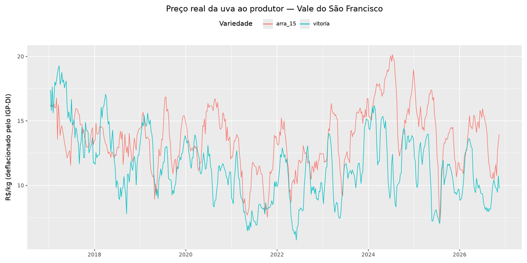

```python
# Visão geral das séries (preço real deflacionado)
plot = (
    p9.ggplot(df.dropna(subset=["y"]), p9.aes("fecha", "y", color="unique_id")) +
    p9.geom_line() +
    p9.scale_x_date(date_breaks="2 years", date_labels="%Y") +
    p9.labs(title="Preço real da uva ao produtor — Vale do São Francisco",
            x="", y="R$/kg (deflacionado pelo IGP-DI)", color="Variedade") +
    p9.theme(legend_position="top")
)
plot.show()
```

### 7.1 Descrição dos dados e estatísticas

A tabela abaixo reporta estatísticas descritivas e testes de raiz unitária. O ADF testa $H_0$: raiz unitária (Dickey e Fuller 1979); o KPSS testa a hipótese oposta, $H_0$: estacionariedade (Kwiatkowski et al. 1992) — usá-los em conjunto evita conclusões frágeis de um único teste. A decisão de diferenciação no pipeline permanece interna ao AutoARIMA (parâmetro $d$, escolhido por testes sequenciais); a tabela documenta a evidência que fundamenta essa escolha.

**Código**

```python
from statsmodels.tsa.stattools import adfuller, kpss

desc = []
for uid in ["arra_15", "vitoria"]:
    s = df[df["unique_id"] == uid].dropna(subset=["y"]).set_index("fecha")["y"]
    adf_p  = adfuller(s, autolag="AIC")[1]
    kpss_p = kpss(s, regression="c", nlags="auto")[1]
    adf_d  = adfuller(s.diff().dropna(), autolag="AIC")[1]
    desc.append({
        "Variedade": uid, "N": len(s),
        "Início": s.index.min().strftime("%Y-%m"),
        "Fim": s.index.max().strftime("%Y-%m"),
        "Média": s.mean(), "DP": s.std(),
        "Mín": s.min(), "Máx": s.max(), "CV (%)": 100 * s.std() / s.mean(),
        "ADF p (nível)": adf_p, "KPSS p (nível)": kpss_p, "ADF p (Δy)": adf_d})

(GT(pd.DataFrame(desc))
 .tab_header(title="Estatísticas descritivas — preço real (R$/kg)",
             subtitle="ADF: H0 = raiz unitária | KPSS: H0 = estacionariedade "
                      "(p do KPSS é limitado ao intervalo tabulado [0,01; 0,10])")
 .fmt_number(columns=["Média", "DP", "Mín", "Máx", "CV (%)"], decimals=2)
 .fmt_number(columns=["ADF p (nível)", "KPSS p (nível)", "ADF p (Δy)"], decimals=3))
```

Estatísticas descritivas — preço real (R$/kg)

ADF: H0 = raiz unitária | KPSS: H0 = estacionariedade (p do KPSS é limitado ao intervalo tabulado [0,01; 0,10])

| Variedade | N | Início | Fim | Média | DP | Mín | Máx | CV (%) | ADF p (nível) | KPSS p (nível) | ADF p (Δy) |
| --- | --- | --- | --- | --- | --- | --- | --- | --- | --- | --- | --- |
| arra_15 | 514 | 2017-01 | 2026-11 | 13.60 | 2.32 | 7.15 | 20.14 | 17.05 | 0.000 | 0.100 | 0.000 |
| vitoria | 514 | 2017-01 | 2026-11 | 11.42 | 2.64 | 5.75 | 19.27 | 23.13 | 0.009 | 0.010 | 0.000 |

## 8. Ponto de partida: comparação univariada (sem exógenas)

Antes de qualquer exógena, estabelecemos o **piso univariado**: o que cada família de modelo consegue extrair **só do histórico do próprio preço**. É a régua contra a qual toda variável adicional terá de “pagar aluguel” no rolling-origin. Competidores, todos sob o **mesmo protocolo** (h=6, 20 origens, passo 4):

- **Benchmarks**: *Naive* (random walk — repete o último preço) e *naive sazonal* (repete o preço da mesma semana do ano anterior);
- **ARIMA** (AutoARIMA, $m=1$): sem termos de Fourier, só enxerga sazonalidade pelo que a parte AR alcançar — esperamos que sofra em h=6;
- **SARIMA-52** (AutoARIMA, $m=52$): a forma clássica de sazonalidade em ARIMA; incluído aqui como teste empírico, apesar das reservas teóricas (§4.1). A busca stepwise irrestrita é computacionalmente proibitiva com $m=52$ (mais de 40 min sem concluir as 20 origens), o que já é, por si, um resultado operacional relevante; usamos busca restrita ($P,D,Q\le 1$; $p,q\le 3$; aproximação CSS na seleção) para viabilizar a comparação;
- **Machine Learning**: **XGBoost** e **LightGBM**, ambos apenas com as defasagens $y_{t-1}, y_{t-2}, y_{t-4}, y_{t-52}$ (hiperparâmetros do §4.2);
- **Redes neurais**: **NHITS** (arquitetura detalhada na §4.3) e **MLP** (`neuralforecast`, CPU, seed fixa), janela de entrada de 104 semanas (2 anos). Por custo computacional, as redes treinam **uma única vez** na primeira origem (`refit=False`) e preveem as demais janelas sem reestimação — leve desvantagem informacional frente aos modelos reestimados a cada origem, a ser lembrada na leitura.

**Código**

```python
import logging
import lightgbm as lgb
from statsforecast.models import Naive
logging.getLogger("pytorch_lightning").setLevel(logging.ERROR)
from neuralforecast import NeuralForecast
from neuralforecast.models import NHITS, MLP

base = df[["unique_id", "ds", "y"]].copy()
refy_u = {uid: g.set_index("ds")["y"] for uid, g in base.groupby("unique_id")}
esc_u  = {uid: float(g["y"].diff(52).abs().mean()) for uid, g in base.groupby("unique_id")}

def metr_uni(cv, modelo, uid):
    s = cv[cv["unique_id"] == uid].copy()
    s["yc"] = s["cutoff"].map(refy_u[uid])
    y, p, yc = s["y"].values, s[modelo].values, s["yc"].values
    err = p - y
    return {"Variedade": uid, "Modelo": modelo,
            "RMSE": float(np.sqrt((err ** 2).mean())),
            "MAPE (%)": float((np.abs(err) / y).mean() * 100),
            "MASE": float(np.abs(err).mean() / esc_u[uid]),
            "Dir.Acc (%)": float((np.sign(p - yc) == np.sign(y - yc)).mean() * 100)}

# Estatísticos. O SARIMA-52 com busca stepwise irrestrita é computacionalmente
# proibitivo (a rodada completa passou de 40 min sem terminar); a busca aqui é
# restrita (P,D,Q <= 1; p,q <= 3; approximation=True) — restrição registrada
# na leitura dos resultados.
sf_uni = StatsForecast(models=[Naive(), SeasonalNaive(season_length=52),
                               AutoARIMA(season_length=1,  alias="ARIMA"),
                               AutoARIMA(season_length=52, max_p=3, max_q=3,
                                         max_P=1, max_D=1, max_Q=1,
                                         approximation=True, alias="SARIMA-52")],
                       freq=1, n_jobs=1)
cv_sfu = sf_uni.cross_validation(df=base, h=H, n_windows=N_WIN, step_size=STEP)

# ML: mesmas defasagens e hiperparâmetros do pipeline, sem exógenas
ml_uni = MLForecast(models={
    "XGBoost":  xgb.XGBRegressor(n_estimators=200, max_depth=3, learning_rate=0.05,
                                 verbosity=0, random_state=42),
    "LightGBM": lgb.LGBMRegressor(n_estimators=200, max_depth=3, learning_rate=0.05,
                                  verbosity=-1, random_state=42)},
    freq=1, lags=[1, 2, 4, 52])
cv_mlu = ml_uni.cross_validation(df=base, h=H, n_windows=N_WIN, step_size=STEP,
                                 static_features=[])

# Redes neurais: treinadas uma vez na primeira origem (refit=False)
nf_uni = NeuralForecast(models=[
    NHITS(h=H, input_size=INPUT_SIZE, max_steps=500, random_seed=42,
          scaler_type="robust", enable_progress_bar=False, logger=False),
    MLP(h=H, input_size=INPUT_SIZE, max_steps=500, random_seed=42,
        scaler_type="robust", enable_progress_bar=False, logger=False)], freq=1)
cv_nfu = nf_uni.cross_validation(df=base, n_windows=N_WIN, step_size=STEP, refit=False)

met_uni = []
for uid in ["arra_15", "vitoria"]:
    for cv_, modelos in [(cv_sfu, ["Naive", "SeasonalNaive", "ARIMA", "SARIMA-52"]),
                         (cv_mlu, ["XGBoost", "LightGBM"]),
                         (cv_nfu, ["NHITS", "MLP"])]:
        for m in modelos:
            met_uni.append(metr_uni(cv_, m, uid))

resumo_uni = (pd.DataFrame(met_uni)
              .sort_values(["Variedade", "RMSE"]).reset_index(drop=True))
(GT(resumo_uni)
 .tab_header(title="Comparação univariada — nenhuma exógena",
             subtitle=f"h={H} semanas, {N_WIN} origens, passo {STEP} "
                      "(MASE < 1 = bate o naive sazonal)")
 .fmt_number(columns=["RMSE", "MAPE (%)", "MASE", "Dir.Acc (%)"], decimals=2))
```

Comparação univariada — nenhuma exógena

h=6 semanas, 20 origens, passo 4 (MASE < 1 = bate o naive sazonal)

| Variedade | Modelo | RMSE | MAPE (%) | MASE | Dir.Acc (%) |
| --- | --- | --- | --- | --- | --- |
| arra_15 | ARIMA | 1.83 | 11.24 | 0.56 | 65.83 |
| arra_15 | SARIMA-52 | 1.84 | 11.30 | 0.56 | 60.00 |
| arra_15 | XGBoost | 1.85 | 11.87 | 0.59 | 37.50 |
| arra_15 | LightGBM | 1.91 | 12.17 | 0.61 | 45.83 |
| arra_15 | Naive | 1.94 | 11.73 | 0.58 | 0.00 |
| arra_15 | NHITS | 2.03 | 12.95 | 0.66 | 60.00 |
| arra_15 | MLP | 2.26 | 14.93 | 0.77 | 67.50 |
| arra_15 | SeasonalNaive | 4.21 | 27.38 | 1.33 | 60.83 |
| vitoria | NHITS | 1.26 | 10.57 | 0.44 | 69.17 |
| vitoria | MLP | 1.38 | 12.03 | 0.51 | 72.50 |
| vitoria | XGBoost | 1.52 | 11.95 | 0.51 | 59.17 |
| vitoria | LightGBM | 1.56 | 11.81 | 0.49 | 66.67 |
| vitoria | SARIMA-52 | 1.61 | 12.49 | 0.52 | 61.67 |
| vitoria | ARIMA | 1.71 | 12.26 | 0.53 | 57.50 |
| vitoria | Naive | 1.73 | 12.54 | 0.54 | 0.00 |
| vitoria | SeasonalNaive | 2.60 | 23.49 | 0.96 | 57.50 |

Esta tabela define o **piso**: das seções seguintes em diante, as exógenas (Fourier, Niño, câmbio — e depois clima de uva) só entram se melhorarem o que os melhores modelos univariados já entregam.

### 8.1 As diferenças univariadas são significativas? (DM e PT)

Com 20 origens, diferenças pequenas de RMSE podem ser sorte. Aplicamos **Diebold-Mariano** (perda quadrática, correção de Harvey-Leybourne-Newbold, variância HAC — os erros multi-passo são autocorrelacionados até $h-1=5$; como as janelas se sobrepõem parcialmente, os p-valores são aproximações conservadoras) às comparações que importam para a decisão de arquitetura: o **NHITS** (primeiro colocado da tabela acima na maioria das rodadas) contra cada rival relevante, e os modelos de ML contra o random walk. A acurácia direcional dos quatro melhores é testada com **Pesaran-Timmermann**.

**Código**

```python
from scipy import stats


def dm_hln(e1, e2, h):
    """Diebold-Mariano (perda quadrática) com correção HLN e HAC-Bartlett."""
    d = e1**2 - e2**2
    n = len(d)
    dbar = float(d.mean())
    dc = d - dbar
    var = float(dc @ dc) / n
    for k in range(1, h):
        var += 2 * (1 - k / h) * float(dc[k:] @ dc[:-k]) / n
    dm = dbar / np.sqrt(var / n)
    hln = dm * np.sqrt((n + 1 - 2 * h + h * (h - 1) / n) / n)
    return float(hln), float(2 * stats.t.sf(abs(hln), df=n - 1))


def pt_test(pred, real, yc):
    """Pesaran-Timmermann (unilateral) para direção vs. último observado."""
    x = (pred > yc).astype(float)
    y = (real > yc).astype(float)
    n = len(x)
    px, py = x.mean(), y.mean()
    phat = float((x == y).mean())
    pstar = px * py + (1 - px) * (1 - py)
    v_hat = pstar * (1 - pstar) / n
    v_star = ((2 * py - 1)**2 * px * (1 - px) + (2 * px - 1)**2 * py * (1 - py)
              + 4 * px * py * (1 - px) * (1 - py) / n) / n
    if v_hat - v_star <= 0:
        return np.nan, np.nan
    z = (phat - pstar) / np.sqrt(v_hat - v_star)
    return float(z), float(stats.norm.sf(z))


# erros alinhados janela a janela (mesmos cutoffs nos três cross-validations)
cv_uni = (cv_sfu
          .merge(cv_mlu[["unique_id", "ds", "cutoff", "XGBoost", "LightGBM"]],
                 on=["unique_id", "ds", "cutoff"])
          .merge(cv_nfu[["unique_id", "ds", "cutoff", "NHITS", "MLP"]],
                 on=["unique_id", "ds", "cutoff"]))

COMP_UNI = [("NHITS", "XGBoost"), ("NHITS", "MLP"), ("NHITS", "ARIMA"),
            ("NHITS", "Naive"), ("XGBoost", "Naive"), ("XGBoost", "LightGBM")]
dm_uni, pt_uni = [], []
for uid in ["arra_15", "vitoria"]:
    cvu = cv_uni[cv_uni["unique_id"] == uid].sort_values(["cutoff", "ds"]).reset_index(drop=True)
    cvu["yc"] = cvu["cutoff"].map(refy_u[uid])
    for m1, m2 in COMP_UNI:
        e1 = (cvu[m1] - cvu["y"]).values
        e2 = (cvu[m2] - cvu["y"]).values
        t, p = dm_hln(e1, e2, H)
        dm_uni.append({"Variedade": uid, "Comparação": f"{m1} vs {m2}",
                       "DM (HLN)": t, "p-valor": p,
                       "Conclusão": ("primeiro melhor" if t < 0 else "segundo melhor")
                                    + (" *" if p < 0.10 else " (n.s.)")})
    for m in ["NHITS", "MLP", "XGBoost", "LightGBM"]:
        z, p = pt_test(cvu[m].values, cvu["y"].values, cvu["yc"].values)
        pt_uni.append({"Variedade": uid, "Modelo": m, "PT (z)": z, "p-valor": p,
                       "Conteúdo direcional": "sim *" if p < 0.10 else "não comprovado"})

(GT(pd.DataFrame(dm_uni))
 .tab_header(title="DM (HLN) — comparação univariada",
             subtitle="DM < 0 favorece o primeiro modelo; * = significativo a 10%")
 .fmt_number(columns=["DM (HLN)", "p-valor"], decimals=3))
```

DM (HLN) — comparação univariada

DM < 0 favorece o primeiro modelo; * = significativo a 10%

| Variedade | Comparação | DM (HLN) | p-valor | Conclusão |
| --- | --- | --- | --- | --- |
| arra_15 | NHITS vs XGBoost | 1.040 | 0.300 | segundo melhor (n.s.) |
| arra_15 | NHITS vs MLP | −2.440 | 0.016 | primeiro melhor * |
| arra_15 | NHITS vs ARIMA | 1.177 | 0.242 | segundo melhor (n.s.) |
| arra_15 | NHITS vs Naive | 0.461 | 0.646 | segundo melhor (n.s.) |
| arra_15 | XGBoost vs Naive | −0.924 | 0.358 | primeiro melhor (n.s.) |
| arra_15 | XGBoost vs LightGBM | −0.972 | 0.333 | primeiro melhor (n.s.) |
| vitoria | NHITS vs XGBoost | −1.395 | 0.165 | primeiro melhor (n.s.) |
| vitoria | NHITS vs MLP | −1.190 | 0.236 | primeiro melhor (n.s.) |
| vitoria | NHITS vs ARIMA | −1.502 | 0.136 | primeiro melhor (n.s.) |
| vitoria | NHITS vs Naive | −1.553 | 0.123 | primeiro melhor (n.s.) |
| vitoria | XGBoost vs Naive | −1.375 | 0.172 | primeiro melhor (n.s.) |
| vitoria | XGBoost vs LightGBM | −0.286 | 0.775 | primeiro melhor (n.s.) |

**Código**

```python
(GT(pd.DataFrame(pt_uni))
 .tab_header(title="Pesaran-Timmermann — comparação univariada",
             subtitle="H0: direção prevista independente da realizada; * = significativo a 10%")
 .fmt_number(columns=["PT (z)", "p-valor"], decimals=3))
```

Pesaran-Timmermann — comparação univariada

H0: direção prevista independente da realizada; * = significativo a 10%

| Variedade | Modelo | PT (z) | p-valor | Conteúdo direcional |
| --- | --- | --- | --- | --- |
| arra_15 | NHITS | 2.423 | 0.008 | sim * |
| arra_15 | MLP | 4.027 | 0.000 | sim * |
| arra_15 | XGBoost | −2.814 | 0.998 | não comprovado |
| arra_15 | LightGBM | −0.937 | 0.826 | não comprovado |
| vitoria | NHITS | 5.151 | 0.000 | sim * |
| vitoria | MLP | 5.645 | 0.000 | sim * |
| vitoria | XGBoost | 2.559 | 0.005 | sim * |
| vitoria | LightGBM | 4.232 | 0.000 | sim * |

**Nota**

**Sobre os números citados no texto.** Este documento é re-renderizado a cada atualização semanal, e as tabelas acima sempre refletem os dados mais recentes. Os p-valores e RMSE mencionados na prosa referem-se a **rodadas de referência** e podem oscilar de uma semana para outra — o que se busca registrar são as **conclusões que se mantêm estáveis** entre rodadas. Quando uma conclusão depende de um número específico, ele é apresentado como evidência daquela rodada, não como constante do fenômeno.

Consequência para a arquitetura, adotada na §9: **combinar NHITS + XGBoost**, ambos univariados, por média simples. Não é a escolha de um campeão — é o reconhecimento de que os dois erram de formas diferentes (§4.3) e que nenhum teste autoriza descartar o outro. Os experimentos seguintes (§8.2 em diante) testam exógenas **uma a uma** sobre essa base.

### 8.2 Primeira exógena candidata: Fourier (K=2 vs K=3) — testada e descartada

A primeira candidata da fila era a sazonalidade determinística por termos de Fourier (§4.1) — espinha dorsal do modelo da manga, onde `AutoARIMA(m=1)` + Fourier superou com folga o SARIMA-52. A hipótese específica da uva era que a sazonalidade **bimodal** (2 podas/ano) pedisse $K=2$ ou $K=3$ harmônicos. Desenho do teste: **três famílias** — XGBoost e NHITS (os dois vencedores da §8.1) e também o **AutoARIMA(m=1)** (a regressão harmônica dinâmica é a especificação campeã da manga, e o ARIMA é o único competidor *sem nenhum mecanismo sazonal próprio*: sem lag 52 e sem decomposição, é nele que o Fourier teria mais chance de ajudar) — cada um em três versões: univariado (controle), +Fourier $K=2$ e +Fourier $K=3$, no mesmo protocolo (h=6, 20 origens, passo 4, seed fixa), com **DM pareado janela a janela** entre cada variante e seu controle. No XGBoost os termos sin/cos entram como atributos junto às defasagens; no NHITS, via `futr_exog_list` (exógenas futuras conhecidas — determinísticas, sem vazamento); no AutoARIMA, como regressores externos (ARIMAX, §4.1). *(SARIMA+Fourier não se testa: seria duplicar o mecanismo sazonal — o Fourier é a alternativa ao SARIMA, não um complemento.)*

**Código**

```python
# Fourier K=3 (K=1,2 já construídos na §7)
for k in (3,):
    df[f"sin{k}"] = np.sin(2 * np.pi * k * doy)
    df[f"cos{k}"] = np.cos(2 * np.pi * k * doy)
F2 = ["sin1", "cos1", "sin2", "cos2"]
F3 = F2 + ["sin3", "cos3"]
base_f = df[["unique_id", "ds", "y"] + F3].copy()

# XGBoost: univariado (controle), +F2, +F3
def xgb_novo():
    return xgb.XGBRegressor(n_estimators=200, max_depth=3, learning_rate=0.05,
                            verbosity=0, random_state=42)
cvs_fx = {}
for nome, cols in [("XGB_univ", []), ("XGB_F2", F2), ("XGB_F3", F3)]:
    mlf_f = MLForecast(models={nome: xgb_novo()}, freq=1, lags=[1, 2, 4, 52])
    cvs_fx[nome] = mlf_f.cross_validation(df=base_f[["unique_id", "ds", "y"] + cols],
                                          h=H, n_windows=N_WIN, step_size=STEP,
                                          static_features=[])

# NHITS: univariado (controle), +F2, +F3 — uma chamada, três aliases
def nhits_f(alias, cols):
    return NHITS(h=H, input_size=INPUT_SIZE, max_steps=500, random_seed=42,
                 scaler_type="robust", enable_progress_bar=False, logger=False,
                 futr_exog_list=cols if cols else None, alias=alias)
nf_f = NeuralForecast(models=[nhits_f("NHITS_univ", None),
                              nhits_f("NHITS_F2", F2),
                              nhits_f("NHITS_F3", F3)], freq=1)
cv_nff = nf_f.cross_validation(df=base_f, n_windows=N_WIN, step_size=STEP, refit=False)

def metr_erro(cv, m, uid):
    s = cv[cv["unique_id"] == uid].sort_values(["cutoff", "ds"])
    s = s.assign(yc=s["cutoff"].map(refy_u[uid]))
    y, p, yc = s["y"].values, s[m].values, s["yc"].values
    err = p - y
    return ({"Variedade": uid, "Modelo": m,
             "RMSE": float(np.sqrt((err ** 2).mean())),
             "MASE": float(np.abs(err).mean() / esc_u[uid]),
             "Dir.Acc (%)": float((np.sign(p - yc) == np.sign(y - yc)).mean() * 100)},
            err)

# AutoARIMA(m=1): univariado (controle), +F2, +F3 — Fourier como regressor (ARIMAX)
cvs_fa = {}
for nome, cols in [("ARIMA_univ", []), ("ARIMA_F2", F2), ("ARIMA_F3", F3)]:
    sf_f = StatsForecast(models=[AutoARIMA(season_length=1, alias=nome)], freq=1, n_jobs=1)
    cvs_fa[nome] = sf_f.cross_validation(df=base_f[["unique_id", "ds", "y"] + cols],
                                         h=H, n_windows=N_WIN, step_size=STEP)

linhas_f, erros_f = [], {}
for uid in ["arra_15", "vitoria"]:
    for nome, cv_ in {**cvs_fx, **cvs_fa}.items():
        r, e = metr_erro(cv_, nome, uid); linhas_f.append(r); erros_f[(uid, nome)] = e
    for nome in ["NHITS_univ", "NHITS_F2", "NHITS_F3"]:
        r, e = metr_erro(cv_nff, nome, uid); linhas_f.append(r); erros_f[(uid, nome)] = e

(GT(pd.DataFrame(linhas_f).sort_values(["Variedade", "RMSE"]).reset_index(drop=True))
 .tab_header(title="Fourier sobre os vencedores univariados",
             subtitle="Controles (univ) vs +Fourier K=2 e K=3 — mesmo rolling-origin da §8")
 .fmt_number(columns=["RMSE", "MASE", "Dir.Acc (%)"], decimals=2))
```

Fourier sobre os vencedores univariados

Controles (univ) vs +Fourier K=2 e K=3 — mesmo rolling-origin da §8

| Variedade | Modelo | RMSE | MASE | Dir.Acc (%) |
| --- | --- | --- | --- | --- |
| arra_15 | ARIMA_univ | 1.83 | 0.56 | 65.83 |
| arra_15 | XGB_univ | 1.85 | 0.59 | 37.50 |
| arra_15 | NHITS_univ | 2.03 | 0.66 | 60.00 |
| arra_15 | XGB_F3 | 2.05 | 0.64 | 32.50 |
| arra_15 | XGB_F2 | 2.05 | 0.64 | 28.33 |
| arra_15 | ARIMA_F2 | 2.16 | 0.66 | 35.00 |
| arra_15 | ARIMA_F3 | 2.23 | 0.66 | 41.67 |
| arra_15 | NHITS_F2 | 2.34 | 0.75 | 54.17 |
| arra_15 | NHITS_F3 | 2.44 | 0.78 | 57.50 |
| vitoria | NHITS_univ | 1.26 | 0.44 | 69.17 |
| vitoria | ARIMA_F3 | 1.49 | 0.48 | 61.67 |
| vitoria | ARIMA_F2 | 1.49 | 0.48 | 64.17 |
| vitoria | NHITS_F3 | 1.51 | 0.56 | 55.83 |
| vitoria | XGB_univ | 1.52 | 0.51 | 59.17 |
| vitoria | XGB_F2 | 1.54 | 0.54 | 53.33 |
| vitoria | XGB_F3 | 1.55 | 0.54 | 55.83 |
| vitoria | NHITS_F2 | 1.56 | 0.58 | 62.50 |
| vitoria | ARIMA_univ | 1.71 | 0.53 | 57.50 |

**Código**

```python
COMP_F = [("XGB_F2", "XGB_univ"), ("XGB_F3", "XGB_univ"), ("XGB_F3", "XGB_F2"),
          ("NHITS_F2", "NHITS_univ"), ("NHITS_F3", "NHITS_univ"), ("NHITS_F3", "NHITS_F2"),
          ("ARIMA_F2", "ARIMA_univ"), ("ARIMA_F3", "ARIMA_univ"), ("ARIMA_F3", "ARIMA_F2")]
dm_f = []
for uid in ["arra_15", "vitoria"]:
    for m1, m2 in COMP_F:
        t, p = dm_hln(erros_f[(uid, m1)], erros_f[(uid, m2)], H)
        dm_f.append({"Variedade": uid, "Comparação": f"{m1} vs {m2}",
                     "DM (HLN)": t, "p-valor": p,
                     "Conclusão": ("primeiro melhor" if t < 0 else "segundo melhor")
                                  + (" *" if p < 0.10 else " (n.s.)")})
(GT(pd.DataFrame(dm_f))
 .tab_header(title="DM (HLN) — o Fourier paga aluguel?",
             subtitle="DM > 0 = a variante com Fourier perde do controle; * = significativo a 10%")
 .fmt_number(columns=["DM (HLN)", "p-valor"], decimals=3))
```

DM (HLN) — o Fourier paga aluguel?

DM > 0 = a variante com Fourier perde do controle; * = significativo a 10%

| Variedade | Comparação | DM (HLN) | p-valor | Conclusão |
| --- | --- | --- | --- | --- |
| arra_15 | XGB_F2 vs XGB_univ | 1.668 | 0.098 | segundo melhor * |
| arra_15 | XGB_F3 vs XGB_univ | 1.609 | 0.110 | segundo melhor (n.s.) |
| arra_15 | XGB_F3 vs XGB_F2 | −0.254 | 0.800 | primeiro melhor (n.s.) |
| arra_15 | NHITS_F2 vs NHITS_univ | 1.072 | 0.286 | segundo melhor (n.s.) |
| arra_15 | NHITS_F3 vs NHITS_univ | 1.248 | 0.214 | segundo melhor (n.s.) |
| arra_15 | NHITS_F3 vs NHITS_F2 | 0.773 | 0.441 | segundo melhor (n.s.) |
| arra_15 | ARIMA_F2 vs ARIMA_univ | 2.399 | 0.018 | segundo melhor * |
| arra_15 | ARIMA_F3 vs ARIMA_univ | 1.868 | 0.064 | segundo melhor * |
| arra_15 | ARIMA_F3 vs ARIMA_F2 | 0.874 | 0.384 | segundo melhor (n.s.) |
| vitoria | XGB_F2 vs XGB_univ | 0.154 | 0.878 | segundo melhor (n.s.) |
| vitoria | XGB_F3 vs XGB_univ | 0.160 | 0.873 | segundo melhor (n.s.) |
| vitoria | XGB_F3 vs XGB_F2 | 0.049 | 0.961 | segundo melhor (n.s.) |
| vitoria | NHITS_F2 vs NHITS_univ | 2.689 | 0.008 | segundo melhor * |
| vitoria | NHITS_F3 vs NHITS_univ | 2.116 | 0.036 | segundo melhor * |
| vitoria | NHITS_F3 vs NHITS_F2 | −0.735 | 0.464 | primeiro melhor (n.s.) |
| vitoria | ARIMA_F2 vs ARIMA_univ | −1.881 | 0.062 | primeiro melhor * |
| vitoria | ARIMA_F3 vs ARIMA_univ | −1.679 | 0.096 | primeiro melhor * |
| vitoria | ARIMA_F3 vs ARIMA_F2 | −0.055 | 0.956 | primeiro melhor (n.s.) |

**Decisões:** (i) Fourier **descartado** para as duas variedades, nas três famílias de modelo — e, por consequência, a especificação vigente do projeto (§9) é **puramente univariada**; (ii) as próximas candidatas (Niño lag 26, câmbio lag 8, clima da uva) serão testadas **sem Fourier**, cada uma contra a especificação vigente; (iii) o AutoARIMA sai da combinação principal: sem Fourier e sem exógenas, ele não se distingue do random walk nesta série (§10).

### 8.3 Hiperparâmetro herdado: a janela de entrada do NHITS — hipótese refutada

O `input_size` do NHITS (104 semanas, 2 anos) veio do template da manga e nunca havia sido examinado. A hipótese que motivou este teste nasceu de um erro observado ao vivo: em três semanas consecutivas de agosto de 2026 a rede projetou **alta** para a BRS Vitória enquanto o preço caía de forma sustentada (§11.2). O raciocínio era que uma janela de dois anos ancoraria a rede num patamar de preço já superado — a série da Vitória vinha de ~13 e estava perto de 8 — e que encurtá-la aceleraria a adaptação ao novo nível.

Havia um argumento adicional a favor de encurtar: três resultados deste documento indicam que **não existe estrutura anual estável** nesta série (o Fourier é nocivo, §8.2; o naive sazonal é o pior modelo, §8; o calendário de colheita desloca por causa da poda programada). Se não há padrão anual a aprender, 104 semanas seriam sobretudo ruído — e 2,6 milhões de parâmetros para ~500 observações é uma razão desconfortável.

**Código**

```python
def nhits_janela(k, alias):
    return NHITS(h=H, input_size=k, max_steps=500, random_seed=42,
                 scaler_type="robust", enable_progress_bar=False,
                 logger=False, alias=alias)

JANELAS = [26, 52, 104, 156]
cv_jan = {}
for k in JANELAS:
    nf_k = NeuralForecast(models=[nhits_janela(k, f"NHITS_{k}")], freq=1)
    c = nf_k.cross_validation(df=base, n_windows=N_WIN, step_size=STEP, refit=False)
    c = c.reset_index() if "unique_id" not in c.columns else c
    m = (cv_mlu[["unique_id", "ds", "cutoff", "y", "XGBoost"]]
         .merge(c[["unique_id", "ds", "cutoff", f"NHITS_{k}"]],
                on=["unique_id", "ds", "cutoff"]))
    m["Comb"] = (m["XGBoost"] + m[f"NHITS_{k}"]) / 2
    m["yc"] = [refy_u[u].loc[int(cc)] for u, cc in zip(m["unique_id"], m["cutoff"])]
    cv_jan[k] = m

lin_jan, err_jan = [], {}
for k in JANELAS:
    for rot, col in [("NHITS", f"NHITS_{k}"), ("Combinação", "Comb")]:
        for uid in ["arra_15", "vitoria"]:
            s = cv_jan[k][cv_jan[k]["unique_id"] == uid].sort_values(["cutoff", "ds"])
            e = (s[col] - s["y"]).values
            err_jan[(k, rot, uid)] = e
            lin_jan.append({"Janela": k, "Modelo": rot, "Variedade": uid,
                "RMSE": float(np.sqrt((e ** 2).mean())),
                "Dir.Acc (%)": float((np.sign(s[col]-s["yc"]) == np.sign(s["y"]-s["yc"])).mean()*100),
                # viés = quanto o modelo projeta de variação a mais que a realizada
                "Viés": float((s[col]-s["yc"]).mean() - (s["y"]-s["yc"]).mean())})

(GT(pd.DataFrame(lin_jan).sort_values(["Modelo", "Variedade", "Janela"]))
 .tab_header(title="Janela de entrada do NHITS (input_size)",
             subtitle="104 é a especificação vigente; viés > 0 = projeta alta a mais que a realizada")
 .fmt_number(columns=["RMSE", "Dir.Acc (%)", "Viés"], decimals=3))
```

Janela de entrada do NHITS (input_size)

104 é a especificação vigente; viés > 0 = projeta alta a mais que a realizada

| Janela | Modelo | Variedade | RMSE | Dir.Acc (%) | Viés |
| --- | --- | --- | --- | --- | --- |
| 26 | Combinação | arra_15 | 1.884 | 58.333 | 0.329 |
| 52 | Combinação | arra_15 | 2.011 | 67.500 | 0.599 |
| 104 | Combinação | arra_15 | 1.729 | 65.000 | 0.374 |
| 156 | Combinação | arra_15 | 1.842 | 60.000 | 0.378 |
| 26 | Combinação | vitoria | 1.807 | 55.000 | 0.469 |
| 52 | Combinação | vitoria | 1.643 | 55.833 | 0.577 |
| 104 | Combinação | vitoria | 1.250 | 69.167 | 0.400 |
| 156 | Combinação | vitoria | 1.417 | 74.167 | 0.398 |
| 26 | NHITS | arra_15 | 2.212 | 60.000 | 0.395 |
| 52 | NHITS | arra_15 | 2.457 | 64.167 | 0.934 |
| 104 | NHITS | arra_15 | 2.029 | 60.000 | 0.485 |
| 156 | NHITS | arra_15 | 2.050 | 60.000 | 0.494 |
| 26 | NHITS | vitoria | 2.261 | 52.500 | 0.558 |
| 52 | NHITS | vitoria | 1.927 | 53.333 | 0.774 |
| 104 | NHITS | vitoria | 1.262 | 69.167 | 0.421 |
| 156 | NHITS | vitoria | 1.457 | 71.667 | 0.416 |

**Código**

```python
dm_jan = []
for rot in ["NHITS", "Combinação"]:
    for uid in ["arra_15", "vitoria"]:
        for k in [26, 52, 156]:
            t, p = dm_hln(err_jan[(k, rot, uid)], err_jan[(104, rot, uid)], H)
            dm_jan.append({"Modelo": rot, "Variedade": uid,
                           "Comparação": f"{k} vs 104",
                           "DM (HLN)": t, "p-valor": p,
                           "Conclusão": ("janela alternativa melhor" if t < 0 else "104 melhor")
                                        + (" *" if p < 0.10 else " (n.s.)")})
(GT(pd.DataFrame(dm_jan))
 .tab_header(title="DM (HLN) — janelas alternativas contra o controle de 104 semanas",
             subtitle="DM > 0 favorece a janela de 104; * = significativo a 10%")
 .fmt_number(columns=["DM (HLN)", "p-valor"], decimals=3))
```

DM (HLN) — janelas alternativas contra o controle de 104 semanas

DM > 0 favorece a janela de 104; * = significativo a 10%

| Modelo | Variedade | Comparação | DM (HLN) | p-valor | Conclusão |
| --- | --- | --- | --- | --- | --- |
| NHITS | arra_15 | 26 vs 104 | 0.728 | 0.468 | 104 melhor (n.s.) |
| NHITS | arra_15 | 52 vs 104 | 0.802 | 0.424 | 104 melhor (n.s.) |
| NHITS | arra_15 | 156 vs 104 | 0.115 | 0.909 | 104 melhor (n.s.) |
| NHITS | vitoria | 26 vs 104 | 2.749 | 0.007 | 104 melhor * |
| NHITS | vitoria | 52 vs 104 | 2.354 | 0.020 | 104 melhor * |
| NHITS | vitoria | 156 vs 104 | 0.868 | 0.387 | 104 melhor (n.s.) |
| Combinação | arra_15 | 26 vs 104 | 1.119 | 0.265 | 104 melhor (n.s.) |
| Combinação | arra_15 | 52 vs 104 | 1.031 | 0.304 | 104 melhor (n.s.) |
| Combinação | arra_15 | 156 vs 104 | 1.330 | 0.186 | 104 melhor (n.s.) |
| Combinação | vitoria | 26 vs 104 | 2.900 | 0.004 | 104 melhor * |
| Combinação | vitoria | 52 vs 104 | 2.615 | 0.010 | 104 melhor * |
| Combinação | vitoria | 156 vs 104 | 1.309 | 0.193 | 104 melhor (n.s.) |

O mecanismo que propus também não se sustenta: se a janela longa ancorasse a rede num patamar velho, o viés cresceria com o tamanho da janela. Não é o que se observa — o viés **não é monotônico**, e a janela de 52 semanas é a mais enviesada de todas, não a de 104.

**Por que isso não contradiz a rejeição do Fourier.** À primeira vista há tensão: dizemos que não existe sazonalidade estável, mas a rede se beneficia de dois anos de memória. A conciliação está em *como* cada mecanismo usa o tempo. O Fourier impõe uma curva anual **presa ao calendário** — obriga o modelo a esperar o mesmo comportamento na semana 40 de todo ano. O NHITS com janela longa aprende a **forma** dos ciclos sem alinhá-los a datas fixas. A uva do VSF tem, sim, estrutura cíclica (a poda gera ~2 ciclos por ano), mas de **fase deslocada** entre anos. Fase variável derruba o termo determinístico e não impede a rede flexível de aprender. Os dois resultados descrevem o mesmo fenômeno por ângulos diferentes.

**Decisão:** manter `input_size = 104`. A hipótese fica registrada como testada e refutada, e o valor herdado passa de “não examinado” a “empiricamente validado”.

### 8.4 Janela de treino e mudança de regime — hipótese refutada

Uma análise paralela deste grupo, sobre o **cronograma de colheita** de uma propriedade do VSF, encontrou indícios de que o padrão sazonal da uva mudou: separando “padrão antigo” (2017–2020) de “padrão novo” (2021–2025), a otimização de calendário construída com a janela recente superou a da série completa em cada um dos quatro últimos anos. Se o regime mudou, treinar os modelos de previsão com nove anos de história poderia estar misturando dois mundos — e essa é uma explicação candidata para o viés de alta persistente na Vitória (§11.2): a rede continuaria esperando uma recuperação que pertencia ao regime anterior.

Antes do teste, uma distinção que é fácil perder de vista e que separa esta seção da anterior:

| Parâmetro | O que controla | Status |
| --- | --- | --- |
| `input_size` (§8.3) | quanto o modelo **olha para trás** ao gerar cada previsão | 104 validado |
| **Janela de treino** (esta seção) | de **quais exemplos históricos** o modelo aprende | em teste |

São independentes: um modelo pode olhar dois anos para trás em cada previsão e ainda assim ter aprendido com exemplos de 2017.

**Código**

```python
CORTES = [2017, 2019, 2021]      # 2017 = série completa (controle)
base_ano = base.merge(df[["unique_id", "ds", "fecha"]], on=["unique_id", "ds"])
base_ano["ano"] = base_ano["fecha"].dt.year

cv_cor, lin_cor, err_cor = {}, [], {}
for corte in CORTES:
    b = (base_ano[base_ano["ano"] >= corte][["unique_id", "ds", "y"]]
         .reset_index(drop=True))
    mlf_c = MLForecast(models={"XGBoost": xgb.XGBRegressor(n_estimators=200,
        max_depth=3, learning_rate=0.05, verbosity=0, random_state=42)},
        freq=1, lags=[1, 2, 4, 52])
    cx = mlf_c.cross_validation(df=b, h=H, n_windows=N_WIN, step_size=STEP,
                                static_features=[])
    nf_c = NeuralForecast(models=[NHITS(h=H, input_size=INPUT_SIZE, max_steps=500,
        random_seed=42, scaler_type="robust", enable_progress_bar=False,
        logger=False)], freq=1)
    cn = nf_c.cross_validation(df=b, n_windows=N_WIN, step_size=STEP, refit=False)
    cn = cn.reset_index() if "unique_id" not in cn.columns else cn
    m = cx.merge(cn[["unique_id", "ds", "cutoff", "NHITS"]], on=["unique_id", "ds", "cutoff"])
    m["Comb"] = (m["XGBoost"] + m["NHITS"]) / 2
    m["yc"] = [refy_u[u].loc[int(cc)] for u, cc in zip(m["unique_id"], m["cutoff"])]
    cv_cor[corte] = m
    n_sem = len(b) // 2
    for rot, col in [("NHITS", "NHITS"), ("XGBoost", "XGBoost"), ("Combinação", "Comb")]:
        for uid in ["arra_15", "vitoria"]:
            s = m[m["unique_id"] == uid].sort_values(["cutoff", "ds"])
            e = (s[col] - s["y"]).values
            err_cor[(corte, rot, uid)] = e
            lin_cor.append({"Treino desde": corte, "Semanas": n_sem, "Modelo": rot,
                "Variedade": uid, "RMSE": float(np.sqrt((e ** 2).mean())),
                "Dir.Acc (%)": float((np.sign(s[col]-s["yc"]) == np.sign(s["y"]-s["yc"])).mean()*100),
                "Viés": float((s[col]-s["yc"]).mean() - (s["y"]-s["yc"]).mean())})

# as origens de avaliação têm de ser idênticas nos três cortes, senão o DM
# compararia pontos diferentes; a asserção falha alto se isso deixar de valer
chaves = {c: set(map(tuple, cv_cor[c][["unique_id", "ds", "cutoff"]].values)) for c in CORTES}
assert all(chaves[c] == chaves[2017] for c in CORTES), "origens divergem entre cortes"

(GT(pd.DataFrame(lin_cor).sort_values(["Modelo", "Variedade", "Treino desde"]))
 .tab_header(title="Janela de treino: série completa vs. cortes em 2019 e 2021",
             subtitle="Mesmas origens de avaliação nos três casos")
 .fmt_number(columns=["RMSE", "Dir.Acc (%)", "Viés"], decimals=3))
```

Janela de treino: série completa vs. cortes em 2019 e 2021

Mesmas origens de avaliação nos três casos

| Treino desde | Semanas | Modelo | Variedade | RMSE | Dir.Acc (%) | Viés |
| --- | --- | --- | --- | --- | --- | --- |
| 2017 | 514 | Combinação | arra_15 | 1.729 | 65.000 | 0.374 |
| 2019 | 410 | Combinação | arra_15 | 1.758 | 63.333 | 0.412 |
| 2021 | 306 | Combinação | arra_15 | 1.792 | 70.000 | 0.714 |
| 2017 | 514 | Combinação | vitoria | 1.250 | 69.167 | 0.400 |
| 2019 | 410 | Combinação | vitoria | 1.456 | 64.167 | 0.504 |
| 2021 | 306 | Combinação | vitoria | 1.582 | 60.833 | 0.850 |
| 2017 | 514 | NHITS | arra_15 | 2.029 | 60.000 | 0.485 |
| 2019 | 410 | NHITS | arra_15 | 1.839 | 60.833 | 0.593 |
| 2021 | 306 | NHITS | arra_15 | 2.096 | 70.000 | 1.028 |
| 2017 | 514 | NHITS | vitoria | 1.262 | 69.167 | 0.421 |
| 2019 | 410 | NHITS | vitoria | 1.309 | 65.833 | 0.523 |
| 2021 | 306 | NHITS | vitoria | 1.567 | 65.000 | 0.945 |
| 2017 | 514 | XGBoost | arra_15 | 1.846 | 37.500 | 0.263 |
| 2019 | 410 | XGBoost | arra_15 | 1.889 | 46.667 | 0.230 |
| 2021 | 306 | XGBoost | arra_15 | 1.833 | 58.333 | 0.399 |
| 2017 | 514 | XGBoost | vitoria | 1.522 | 59.167 | 0.380 |
| 2019 | 410 | XGBoost | vitoria | 1.753 | 55.000 | 0.486 |
| 2021 | 306 | XGBoost | vitoria | 1.994 | 53.333 | 0.756 |

**Código**

```python
dm_cor = []
for rot in ["NHITS", "XGBoost", "Combinação"]:
    for uid in ["arra_15", "vitoria"]:
        for c in [2019, 2021]:
            t, p = dm_hln(err_cor[(c, rot, uid)], err_cor[(2017, rot, uid)], H)
            dm_cor.append({"Modelo": rot, "Variedade": uid,
                           "Comparação": f"desde {c} vs completa",
                           "DM (HLN)": t, "p-valor": p,
                           "Conclusão": ("corte melhor" if t < 0 else "série completa melhor")
                                        + (" *" if p < 0.10 else " (n.s.)")})
(GT(pd.DataFrame(dm_cor))
 .tab_header(title="DM (HLN) — janelas de treino truncadas contra a série completa",
             subtitle="DM > 0 favorece treinar com a série completa; * = significativo a 10%")
 .fmt_number(columns=["DM (HLN)", "p-valor"], decimals=3))
```

DM (HLN) — janelas de treino truncadas contra a série completa

DM > 0 favorece treinar com a série completa; * = significativo a 10%

| Modelo | Variedade | Comparação | DM (HLN) | p-valor | Conclusão |
| --- | --- | --- | --- | --- | --- |
| NHITS | arra_15 | desde 2019 vs completa | −1.357 | 0.177 | corte melhor (n.s.) |
| NHITS | arra_15 | desde 2021 vs completa | 0.249 | 0.804 | série completa melhor (n.s.) |
| NHITS | vitoria | desde 2019 vs completa | 0.508 | 0.613 | série completa melhor (n.s.) |
| NHITS | vitoria | desde 2021 vs completa | 1.686 | 0.094 | série completa melhor * |
| XGBoost | arra_15 | desde 2019 vs completa | 0.385 | 0.701 | série completa melhor (n.s.) |
| XGBoost | arra_15 | desde 2021 vs completa | −0.123 | 0.902 | corte melhor (n.s.) |
| XGBoost | vitoria | desde 2019 vs completa | 1.158 | 0.249 | série completa melhor (n.s.) |
| XGBoost | vitoria | desde 2021 vs completa | 1.978 | 0.050 | série completa melhor * |
| Combinação | arra_15 | desde 2019 vs completa | 0.333 | 0.740 | série completa melhor (n.s.) |
| Combinação | arra_15 | desde 2021 vs completa | 0.428 | 0.669 | série completa melhor (n.s.) |
| Combinação | vitoria | desde 2019 vs completa | 1.527 | 0.129 | série completa melhor (n.s.) |
| Combinação | vitoria | desde 2021 vs completa | 2.776 | 0.006 | série completa melhor * |

**Por que o regime mudou lá e não aqui.** A conciliação está no que cada análise usa. O trabalho de cronograma depende do **padrão sazonal**: qual semana do ano rende mais para cada variedade. Esse padrão mudou, e por isso a janela recente produz recomendações melhores naquele problema. Os modelos deste documento, porém, **não usam sazonalidade de calendário** — foi precisamente o que rejeitamos na §8.2. Eles aprendem dinâmica de curto prazo (defasagens no XGBoost, forma dos ciclos no NHITS), e essa dinâmica parece ter permanecido estável mesmo com o calendário de colheita deslocando. As duas conclusões não se contradizem: falam de objetos diferentes.

**Limitação que impede uma conclusão forte.** Este teste **confunde dois efeitos**: “regime diferente” e “menos dados”. Cortar em 2021 deixa ~182 amostras de treino para uma rede de 2,6 milhões de parâmetros, e o salto no viés tem a assinatura de estimação pobre, não necessariamente de regime certo. O teste limpo seria **pesos decrescentes no tempo** — que reduz a influência do passado remoto sem descartar observação alguma. É viável no XGBoost (`sample_weight`) e trabalhoso no NHITS; fica registrado no §12 como candidato.

**Decisão:** manter o treino com a **série completa**. Segunda hipótese testada e refutada nesta frente — o que, somado à §8.3, delimita bastante o espaço de explicações para o viés de alta da Vitória: não é a janela de entrada nem a janela de treino.

### 8.5 Momentum no XGBoost — testado, com efeito oposto por variedade

O acompanhamento contínuo (§11.2) expôs um defeito de **inflexão**: o modelo acerta a direção mas chega atrasado nas viradas. Na Arra isso apareceu duas vezes com o sinal trocado — primeiro sub-reagindo à velocidade de uma queda de dez semanas consecutivas (a mais longa da série), depois sub-reagindo à retomada, errando a direção nas semanas 38 e 39 de 2026 ao insistir na queda. *Momentum* — médias móveis e média exponencial do próprio preço — é a família de features que ataca exatamente esse comportamento.

A ideia carrega uma evidência contrária: momentum foi **testado e descartado no projeto irmão da manga**, onde piorou o RMSE em 9,8% na Palmer. O argumento para retestar aqui não é teimosia, é **relação sinal-ruído**: o desvio-padrão das variações semanais é de 6,2% na Arra e 7,6% na Vitória, contra 14,3% e 21,0% na Palmer e na Tommy. Numa série três vezes menos volátil, uma média móvel carrega tendência; numa série ruidosa, carrega ruído. É plausível que a mesma feature funcione numa e não na outra por esse motivo — plausível, não demonstrado, e o rolling-origin é quem decide.

Acrescentaram-se ao XGBoost médias móveis de 4 e 8 semanas e uma média exponencial ($\alpha=0{,}3$), mantendo os lags [1, 2, 4, 52] e todos os hiperparâmetros. O NHITS ficou inalterado. Mesmas 20 janelas, mesmo $h=6$. A régua é a do projeto: **acurácia direcional**, com RMSE como informação secundária.

| Acurácia direcional (todos os horizontes, $N=120$) | XGBoost isolado | Combinação com NHITS |
| --- | --- | --- |
| Arra 15 — base | 51,7% | 70,0% |
| Arra 15 — com momentum | **61,7%** | 70,8% |
| BRS Vitória — base | 63,3% | 72,5% |
| BRS Vitória — com momentum | **56,7%** | 66,7% |

**O efeito é oposto nas duas variedades** — e na direção que a economia prevê. A área plantada da Arra 15 é monitorada pelas empresas de genética que detêm a patente da variedade; oferta administrada produz tendências persistentes, que é o regime em que média móvel informa. A BRS Vitória é cultivar pública da Embrapa, propagada livremente: a área cresceu sem controle e os movimentos de preço carregam mais ruído de oferta, de modo que suavizar o passado apenas atrasa a reação. O contraste tem contrapartida no nível de preço: entre 2017–2020 e 2021–2025 a Arra preservou o preço real (−2,0%) enquanto a Vitória perdeu 16,8%.

O Diebold-Mariano (HLN) entre as duas combinações confirma o lado ruim e não o bom: na **Vitória**, $t=+4{,}69$ em $h=2$ e $t=+2{,}93$ em $h=3$ **a favor da base** — significativo. Na **Arra**, todos os sinais favorecem o momentum, mas nenhum passa de $|t|=1{,}09$.

**Decisão: não adotar.** Pela regra do projeto, ganho pequeno sem significância no DM é ruído. O ganho de 0,8 ponto na combinação da Arra é *uma* direção a mais em 120 confrontos, enquanto a perda na Vitória é estatisticamente significativa.

**NotaO achado colateral vale mais que o teste**

O ganho de dez pontos do momentum aparece no **XGBoost isolado e desaparece na combinação**. A leitura é que o NHITS já capturava o sinal de tendência que o momentum acrescenta — e isso explica por que a combinação funciona tão bem: os dois modelos não são redundantes, e o NHITS cobre justamente a dimensão em que o XGBoost é mais fraco. Trocar de aprendiz mantendo o mesmo conjunto de informação tende a não mudar nada; o que muda é acrescentar informação que o outro membro da combinação não tem.

*Nota de precisão:* são 20 janelas, o que dá $N=20$ por horizonte e por variedade, com erro-padrão de cerca de 11 pontos na acurácia direcional. Os números horizonte a horizonte **não são legíveis individualmente**; apenas os agregados de 120 observações, e mesmo esses com erro-padrão de ~4,5 pontos. O $t=+4{,}69$ da Vitória é grande demais para 20 observações com previsões sobrepostas — trata-se aqui como indício consistente com os pontos, não como medida fina.

Esta é a **especificação vigente do projeto**, definida pelo caminho incremental das seções anteriores: **NHITS + XGBoost, ambos univariados** (somente o histórico do próprio preço), combinados por **média simples**. Nenhuma exógena entra: o Fourier foi testado e descartado (§8.2), e as demais candidatas — Niño, câmbio, clima da uva — ainda estão na fila (§12), a serem admitidas uma a uma **somente se** superarem esta especificação no rolling-origin.

| Modelo | Papel |
| --- | --- |
| *naive sazonal* ($m=52$) | benchmark tradicional de série sazonal |
| *Naive* (random walk) | benchmark forte em preços (§4.1) — a régua honesta |
| ARIMA (AutoARIMA, $m=1$) | referência estatística clássica |
| **NHITS** | rede neural com decomposição hierárquica (§4.3) |
| **XGBoost** | boosting com defasagens $y_{t-1},y_{t-2},y_{t-4},y_{t-52}$ (§4.2) |
| **Combinação** | média simples de NHITS e XGBoost (§4.4) |

A escolha de combinar **NHITS + XGBoost** (e não AutoARIMA + XGBoost, como na manga) decorre diretamente da §8.1: o AutoARIMA univariado não se distingue do random walk nesta série, enquanto as duas famílias escolhidas erram de formas diferentes — o NHITS prevê os 6 horizontes de uma vez, com trajetória suave; o XGBoost prevê recursivamente e tende a achatar. Combinar erros pouco correlacionados é o mecanismo clássico de redução de variância (§4.4). Tudo avaliado por `cross_validation` (origem móvel), com RMSE, MAPE, MASE e **acurácia direcional**.

```
treino até semana T   |■■■■■■|  ← janela 1 (h=6 semanas)
treino até semana T+4      |■■■■■■|  ← janela 2
treino até semana T+8           |■■■■■■|  ← janela 3
... (20 janelas no total, passo=4)
```

Os RMSE, MAPE e acurácia direcional reportados na tabela abaixo são a **média sobre essas 20 avaliações fora da amostra** — não de uma única divisão treino/teste, que seria estatisticamente ruidosa.

**Código**

```python
def metr(y, p, yc, escala_mase):
    err = p - y
    return (float(np.sqrt((err ** 2).mean())),
            float((np.abs(err) / y).mean() * 100),
            float(np.abs(err).mean() / escala_mase),
            float((np.sign(p - yc) == np.sign(y - yc)).mean() * 100))


# A combinação reaproveita os cross-validations univariados da §8 — mesmas
# janelas, mesmos modelos, garantindo consistência entre as duas seções.
cv_comb = (cv_sfu[["unique_id", "ds", "cutoff", "y", "Naive", "SeasonalNaive", "ARIMA"]]
           .merge(cv_mlu[["unique_id", "ds", "cutoff", "XGBoost"]],
                  on=["unique_id", "ds", "cutoff"])
           .merge(cv_nfu[["unique_id", "ds", "cutoff", "NHITS"]],
                  on=["unique_id", "ds", "cutoff"]))
cv_comb["Ensemble"] = (cv_comb["NHITS"] + cv_comb["XGBoost"]) / 2

MODELOS = ["SeasonalNaive", "Naive", "ARIMA", "NHITS", "XGBoost", "Ensemble"]
metricas, cvs, escalas = [], {}, {}
for uid in ["arra_15", "vitoria"]:
    cv = cv_comb[cv_comb["unique_id"] == uid].sort_values(["cutoff", "ds"]).reset_index(drop=True)
    cv["yc"] = cv["cutoff"].map(refy_u[uid])
    cvs[uid] = cv          # guardado para DM/PT (§10.2) e conformal (§11)
    escalas[uid] = esc_u[uid]
    for m in MODELOS:
        r = metr(cv["y"].values, cv[m].values, cv["yc"].values, escalas[uid])
        metricas.append({"Variedade": uid, "Modelo": m, "RMSE": r[0],
                         "MAPE (%)": r[1], "MASE": r[2], "Dir.Acc (%)": r[3]})

resumo = pd.DataFrame(metricas).sort_values(["Variedade", "RMSE"]).reset_index(drop=True)
(GT(resumo)
 .tab_header(title="Acurácia em rolling-origin — especificação vigente (univariada)",
             subtitle=f"h={H} semanas, {N_WIN} origens, passo {STEP} "
                      "(menor RMSE/MAPE/MASE = melhor; MASE < 1 = bate o naive sazonal)")
 .fmt_number(columns=["RMSE", "MAPE (%)", "MASE", "Dir.Acc (%)"], decimals=2))
```

Acurácia em rolling-origin — especificação vigente (univariada)

h=6 semanas, 20 origens, passo 4 (menor RMSE/MAPE/MASE = melhor; MASE < 1 = bate o naive sazonal)

| Variedade | Modelo | RMSE | MAPE (%) | MASE | Dir.Acc (%) |
| --- | --- | --- | --- | --- | --- |
| arra_15 | Ensemble | 1.73 | 10.70 | 0.53 | 65.00 |
| arra_15 | ARIMA | 1.83 | 11.24 | 0.56 | 65.83 |
| arra_15 | XGBoost | 1.85 | 11.87 | 0.59 | 37.50 |
| arra_15 | Naive | 1.94 | 11.73 | 0.58 | 0.00 |
| arra_15 | NHITS | 2.03 | 12.95 | 0.66 | 60.00 |
| arra_15 | SeasonalNaive | 4.21 | 27.38 | 1.33 | 60.83 |
| vitoria | Ensemble | 1.25 | 10.21 | 0.43 | 69.17 |
| vitoria | NHITS | 1.26 | 10.57 | 0.44 | 69.17 |
| vitoria | XGBoost | 1.52 | 11.95 | 0.51 | 59.17 |
| vitoria | ARIMA | 1.71 | 12.26 | 0.53 | 57.50 |
| vitoria | Naive | 1.73 | 12.54 | 0.54 | 0.00 |
| vitoria | SeasonalNaive | 2.60 | 23.49 | 0.96 | 57.50 |

**Código**

```python
# Previsão fora da amostra: reestimada com TODA a amostra (univariada)
mlf_final = MLForecast(models={"XGBoost": xgb.XGBRegressor(
    n_estimators=200, max_depth=3, learning_rate=0.05, verbosity=0,
    random_state=42)}, freq=1, lags=[1, 2, 4, 52])
mlf_final.fit(base[["unique_id", "ds", "y"]], static_features=[])
f_ml = mlf_final.predict(h=H)

nf_final = NeuralForecast(models=[NHITS(h=H, input_size=INPUT_SIZE, max_steps=500,
                                        random_seed=42, scaler_type="robust",
                                        enable_progress_bar=False, logger=False)], freq=1)
nf_final.fit(df=base[["unique_id", "ds", "y"]])
f_nf = nf_final.predict()
f_nf = f_nf.reset_index() if "unique_id" not in f_nf.columns else f_nf

fc = f_ml.merge(f_nf[["unique_id", "ds", "NHITS"]], on=["unique_id", "ds"])
fc["Ensemble"] = (fc["NHITS"] + fc["XGBoost"]) / 2
fc["h"] = fc.groupby("unique_id").cumcount() + 1

# datas futuras (semanas seguintes à última observada de cada série)
ult_fecha = df.groupby("unique_id")["fecha"].max()
fc["fecha"] = [ult_fecha[u] + pd.Timedelta(weeks=int(h))
               for u, h in zip(fc["unique_id"], fc["h"])]

# Intervalos conformais: quantis por horizonte dos erros absolutos de cada
# modelo no rolling-origin (split-conformal, mesmo critério para os três)
for uid in ["arra_15", "vitoria"]:
    cv = cvs[uid]
    horiz = (cv["ds"] - cv["cutoff"]).astype(int)
    m = fc["unique_id"] == uid
    for modelo in ["NHITS", "XGBoost", "Ensemble"]:
        err = np.abs(cv[modelo] - cv["y"])
        for nivel in (60, 80):
            q = err.groupby(horiz).quantile(nivel / 100)
            fc.loc[m, f"{modelo}-lo-{nivel}"] = fc.loc[m, modelo] - fc.loc[m, "h"].map(q)
            fc.loc[m, f"{modelo}-hi-{nivel}"] = fc.loc[m, modelo] + fc.loc[m, "h"].map(q)
```

## 10. Resultados e interpretação

**Código**

```python
# Ganho de cada modelo vs naive sazonal (RMSE)
piv = resumo.pivot(index="Variedade", columns="Modelo", values="RMSE")
ganho = (1 - piv[["NHITS", "XGBoost", "Ensemble"]].div(piv["SeasonalNaive"], axis=0)) * 100
ganho = ganho.round(1).reset_index()
(GT(ganho).tab_header(title="Redução de RMSE vs. naive sazonal (%)",
                      subtitle="maior = melhor")
 .fmt_number(columns=["NHITS", "XGBoost", "Ensemble"], decimals=1))
```

Redução de RMSE vs. naive sazonal (%)

maior = melhor

| Variedade | NHITS | XGBoost | Ensemble |
| --- | --- | --- | --- |
| arra_15 | 51.8 | 56.2 | 58.9 |
| vitoria | 51.4 | 41.4 | 51.9 |

**O que os números mostram** (rodada de referência: dados até a semana 30/2026 — os valores exatos se atualizam a cada semana, as conclusões qualitativas têm se mantido estáveis):

### 10.1 Diagnóstico de ajuste dentro da amostra

Os gráficos abaixo sobrepõem o preço observado com o ajuste de cada modelo **dentro da amostra** (previsão um passo à frente, usando defasagens reais observadas). Um bom ajuste in-sample é necessário, mas não suficiente — o que valida o modelo é o *rolling-origin* (§9). A comparação revela dois padrões opostos:

- **Sobreajuste (*overfitting*):** ajuste quase perfeito na amostra de treino, mas desempenho pior fora. O XGBoost, com acesso a `lag_1` (preço da semana imediatamente anterior), é o mais suscetível: com esse regressor, ele consegue “enxergar” o nível atual da série e tende a colar na curva observada.
- **Subajuste (*underfitting*):** modelo que não captura padrões sistemáticos — por exemplo, ignorar a sazonalidade anual. Manifesta-se como uma curva suave e deslocada dos picos e vales sazonais.

**Nota**

**Por que a linha do NHITS começa depois da do XGBoost.** A rede precisa de `INPUT_SIZE` = 104 semanas (2 anos) de histórico para formar sua janela de entrada. Nas origens iniciais esse histórico não existe, e o `predict_insample` completa a janela **com zeros** (`ConstantPad1d`) — o “ajuste” daí resultante mede o padding, não o modelo. O efeito é grande e mensurável: nesta série, o erro absoluto médio do NHITS é ~4,4 nas 26 primeiras semanas e ~0,02 depois da 104ª; no primeiro ponto, com a janela inteiramente zerada, a saída da rede vai a praticamente zero. Por isso as 104 primeiras origens são **descartadas** do gráfico: mantê-las sugeriria um subajuste grosseiro que é artefato de janela vazia, não comportamento do modelo. O XGBoost não tem esse problema porque suas defasagens máximas são de 52 semanas e o `mlforecast` simplesmente não gera linha antes disso.

**Código**

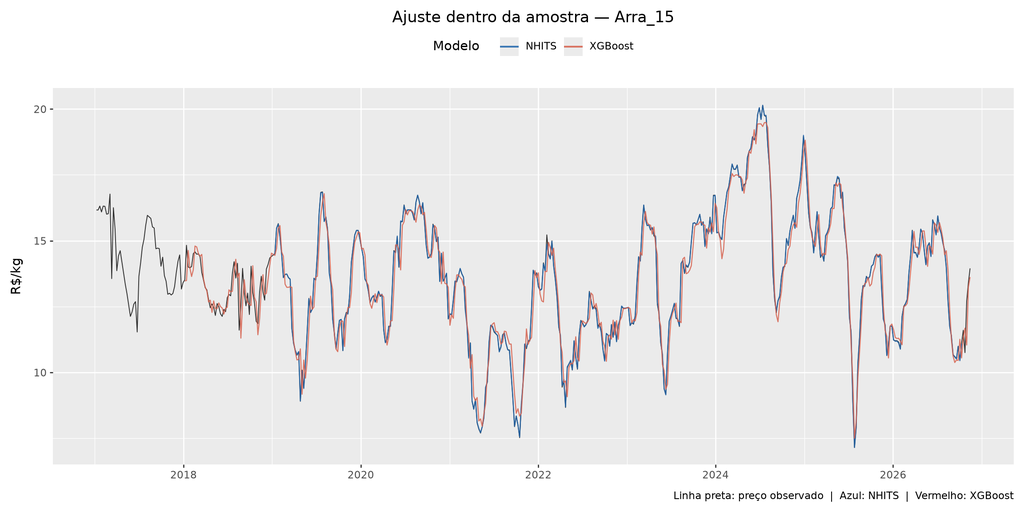

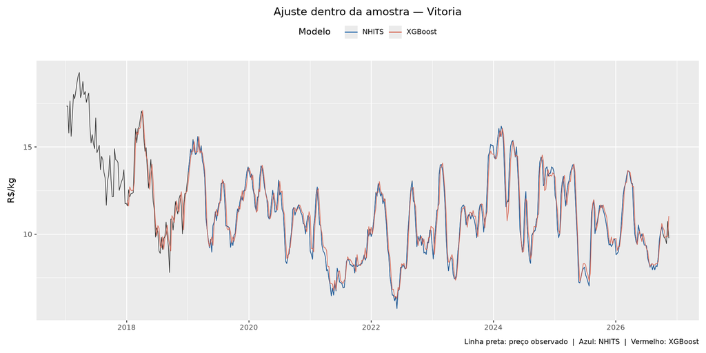

```python
# Ajuste dentro da amostra (um passo à frente) — NHITS e XGBoost univariados
ds_to_fecha = {(u, d): f for u, d, f in zip(df["unique_id"], df["ds"], df["fecha"])}
fits = []

# XGBoost: fitted values do mlforecast
mlf_is = MLForecast(models={"XGBoost": xgb.XGBRegressor(
    n_estimators=200, max_depth=3, learning_rate=0.05, verbosity=0,
    random_state=42)}, freq=1, lags=[1, 2, 4, 52])
mlf_is.fit(base[["unique_id", "ds", "y"]], static_features=[], fitted=True)
iml = mlf_is.forecast_fitted_values().rename(columns={"XGBoost": "ajuste"})
iml["modelo"] = "XGBoost"
fits.append(iml[["unique_id", "ds", "ajuste", "modelo"]])

# NHITS: predict_insample devolve previsões por origem; h=1 isola o passo à frente.
# As INPUT_SIZE primeiras origens são descartadas: sem histórico suficiente, a rede
# preenche a janela de entrada com zeros (ConstantPad1d) e o "ajuste" resultante
# reflete o padding, não o modelo — em ds=0 a janela é toda zero e a saída vai a ~0.
# Medido nesta série: MAE ~4,4 nas 26 primeiras semanas vs ~0,02 após a 104ª.
ins = nf_final.predict_insample(step_size=1)
ins = ins.reset_index() if "unique_id" not in ins.columns else ins
ins = ins[(ins["ds"] - ins["cutoff"]) == 1].rename(columns={"NHITS": "ajuste"})
ins = ins[ins["ds"] >= INPUT_SIZE]          # descarta janelas com padding
ins["modelo"] = "NHITS"
fits.append(ins[["unique_id", "ds", "ajuste", "modelo"]])

fits_df = pd.concat(fits, ignore_index=True).dropna(subset=["ajuste"])
fits_df["fecha"] = [ds_to_fecha.get((u, d)) for u, d in zip(fits_df["unique_id"], fits_df["ds"])]
fits_df = fits_df.dropna(subset=["fecha"])
obs_all = df[["unique_id", "fecha", "y"]].dropna(subset=["y"])

for uid in ["arra_15", "vitoria"]:
    obs_u = obs_all[obs_all["unique_id"] == uid]
    fit_u = fits_df[fits_df["unique_id"] == uid]
    plot = (
        p9.ggplot()
        + p9.geom_line(obs_u, p9.aes("fecha", "y"), color="black", size=0.4, alpha=0.8)
        + p9.geom_line(fit_u, p9.aes("fecha", "ajuste", color="modelo"), size=0.5, alpha=0.85)
        + p9.scale_color_manual(values={"NHITS": "#2166ac", "XGBoost": "#d6604d"})
        + p9.scale_x_date(date_breaks="2 years", date_labels="%Y")
        + p9.labs(
            title=f"Ajuste dentro da amostra — {uid.capitalize()}",
            caption="Linha preta: preço observado  |  Azul: NHITS  |  Vermelho: XGBoost",
            x="", y="R$/kg", color="Modelo")
        + p9.theme(legend_position="top")
    )
    plot.show()
```

### 10.2 Significância estatística das diferenças (DM e PT)

As diferenças de RMSE da tabela do §9 são formalmente testadas com **Diebold-Mariano** (correção de Harvey-Leybourne-Newbold, variância HAC com defasagem $h-1=5$ — os erros multi-passo são autocorrelacionados por construção; como as janelas se sobrepõem parcialmente, os p-valores devem ser lidos como aproximações conservadoras). A **acurácia direcional** é testada com **Pesaran-Timmermann** contra a hipótese de ausência de conteúdo direcional.

**Código**

```python
# dm_hln e pt_test definidos na §8.1
COMPARACOES = [("Ensemble", "SeasonalNaive"), ("Ensemble", "Naive"),
               ("NHITS", "Naive"), ("XGBoost", "Naive"),
               ("Ensemble", "NHITS"), ("Ensemble", "XGBoost"),
               ("NHITS", "XGBoost"), ("NHITS", "ARIMA")]
linhas_dm, linhas_pt = [], []
for uid in ["arra_15", "vitoria"]:
    cv = cvs[uid].sort_values(["cutoff", "ds"]).reset_index(drop=True)
    for m1, m2 in COMPARACOES:
        e1 = (cv[m1] - cv["y"]).values
        e2 = (cv[m2] - cv["y"]).values
        t, p = dm_hln(e1, e2, H)
        linhas_dm.append({"Variedade": uid, "Comparação": f"{m1} vs {m2}",
                          "DM (HLN)": t, "p-valor": p,
                          "Conclusão": ("primeiro melhor" if t < 0 else "segundo melhor")
                                       + (" *" if p < 0.10 else " (n.s.)")})
    for m in ["NHITS", "XGBoost", "Ensemble"]:
        z, p = pt_test(cv[m].values, cv["y"].values, cv["yc"].values)
        linhas_pt.append({"Variedade": uid, "Modelo": m, "PT (z)": z, "p-valor": p,
                          "Conteúdo direcional": "sim *" if p < 0.10 else "não comprovado"})

(GT(pd.DataFrame(linhas_dm))
 .tab_header(title="Teste de Diebold-Mariano (perda quadrática, HLN)",
             subtitle="DM < 0 favorece o primeiro modelo; * = significativo a 10%")
 .fmt_number(columns=["DM (HLN)", "p-valor"], decimals=3))
```

Teste de Diebold-Mariano (perda quadrática, HLN)

DM < 0 favorece o primeiro modelo; * = significativo a 10%

| Variedade | Comparação | DM (HLN) | p-valor | Conclusão |
| --- | --- | --- | --- | --- |
| arra_15 | Ensemble vs SeasonalNaive | −2.872 | 0.005 | primeiro melhor * |
| arra_15 | Ensemble vs Naive | −1.869 | 0.064 | primeiro melhor * |
| arra_15 | NHITS vs Naive | 0.461 | 0.646 | segundo melhor (n.s.) |
| arra_15 | XGBoost vs Naive | −0.924 | 0.358 | primeiro melhor (n.s.) |
| arra_15 | Ensemble vs NHITS | −2.249 | 0.026 | primeiro melhor * |
| arra_15 | Ensemble vs XGBoost | −1.375 | 0.172 | primeiro melhor (n.s.) |
| arra_15 | NHITS vs XGBoost | 1.040 | 0.300 | segundo melhor (n.s.) |
| arra_15 | NHITS vs ARIMA | 1.177 | 0.242 | segundo melhor (n.s.) |
| vitoria | Ensemble vs SeasonalNaive | −4.128 | 0.000 | primeiro melhor * |
| vitoria | Ensemble vs Naive | −2.075 | 0.040 | primeiro melhor * |
| vitoria | NHITS vs Naive | −1.553 | 0.123 | primeiro melhor (n.s.) |
| vitoria | XGBoost vs Naive | −1.375 | 0.172 | primeiro melhor (n.s.) |
| vitoria | Ensemble vs NHITS | −0.120 | 0.905 | primeiro melhor (n.s.) |
| vitoria | Ensemble vs XGBoost | −2.685 | 0.008 | primeiro melhor * |
| vitoria | NHITS vs XGBoost | −1.395 | 0.165 | primeiro melhor (n.s.) |
| vitoria | NHITS vs ARIMA | −1.502 | 0.136 | primeiro melhor (n.s.) |

**Código**

```python
(GT(pd.DataFrame(linhas_pt))
 .tab_header(title="Teste de Pesaran-Timmermann (acurácia direcional)",
             subtitle="H0: direção prevista independente da realizada; * = significativo a 10%")
 .fmt_number(columns=["PT (z)", "p-valor"], decimals=3))
```

Teste de Pesaran-Timmermann (acurácia direcional)

H0: direção prevista independente da realizada; * = significativo a 10%

| Variedade | Modelo | PT (z) | p-valor | Conteúdo direcional |
| --- | --- | --- | --- | --- |
| arra_15 | NHITS | 2.423 | 0.008 | sim * |
| arra_15 | XGBoost | −2.814 | 0.998 | não comprovado |
| arra_15 | Ensemble | 3.577 | 0.000 | sim * |
| vitoria | NHITS | 5.151 | 0.000 | sim * |
| vitoria | XGBoost | 2.559 | 0.005 | sim * |
| vitoria | Ensemble | 5.461 | 0.000 | sim * |

Com apenas 20 origens, o poder dos testes é limitado — diferenças pequenas de RMSE dificilmente serão significativas, e isso é informativo por si só: ganhos que não passam no DM não devem ser vendidos como superioridade de modelo. É por esse critério que o Fourier foi descartado (§8.2) e que a combinação, e não um modelo isolado, foi adotada como especificação vigente: ela é a única que supera o **random walk** com significância nas duas variedades, e supera cada um de seus próprios componentes em pelo menos uma delas.

## 11. Previsão fora da amostra

Reestimado com toda a amostra (NHITS + XGBoost univariados, §9); intervalos **conformais** — livres de distribuição, com garantia de cobertura sob a hipótese de trocabilidade dos erros (Vovk et al. 2005). Os três intervalos (NHITS, XGBoost e combinação) são obtidos pelo **mesmo critério**: quantis por horizonte dos erros absolutos de cada modelo no rolling-origin do §9 (split-conformal). Para a combinação, isso significa conformalizar os erros **do próprio ensemble** — e não a média das bandas individuais, que não teria garantia formal.

O modelo não acerta o ponto, e fingir que acerta (“o preço da próxima semana será R$ 14,28”) é falsa precisão. Por isso a entrega é o **intervalo**, não o ponto. O gráfico apresenta a **faixa central de 60%**: em três de cada cinco semanas históricas análogas, o preço real ficou dentro dela.

**Só a banda de 60% é reportada.** Faixas mais largas (80%, 95%) são progressivamente mais fáceis de cumprir e progressivamente menos úteis para decidir — em preço de perecível, ficam tão amplas que deixam de restringir qualquer escolha. O critério de avaliação do projeto (§11.2) usa apenas **direção** e **cobertura de 60%**, e a apresentação segue esse critério. Os limites de 80% continuam sendo calculados e gravados no histórico — custam nada e preservam a opção de revisitar —, mas não entram em gráfico nem em tabela. A §11.1 verifica se a cobertura de 60% se cumpre de fato.

**Código**

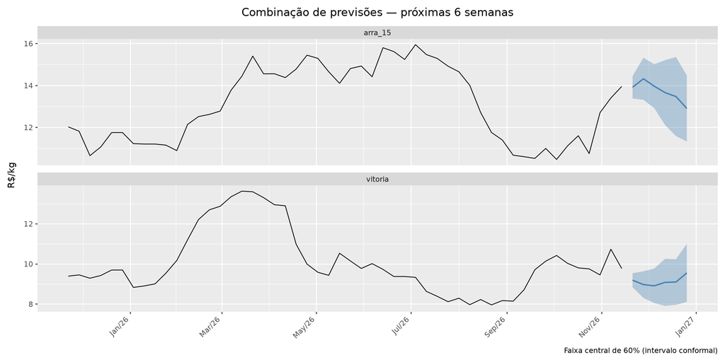

```python
hist = (df.dropna(subset=["y"]).groupby("unique_id").tail(52)
        [["unique_id", "fecha", "y"]].rename(columns={"y": "valor"}))

prev = fc[["unique_id", "fecha", "Ensemble",
           "Ensemble-lo-60", "Ensemble-hi-60",
           "Ensemble-lo-80", "Ensemble-hi-80"]].copy()
prev.columns = ["unique_id", "fecha", "valor", "lo60", "hi60", "lo80", "hi80"]

plot = (
    p9.ggplot()
    + p9.geom_ribbon(prev, p9.aes(x="fecha", ymin="lo60", ymax="hi60"),
                     alpha=0.35, fill="steelblue")
    + p9.geom_line(hist, p9.aes("fecha", "valor"))
    + p9.geom_line(prev, p9.aes("fecha", "valor"), color="steelblue", size=0.9)
    + p9.facet_wrap("unique_id", scales="free_y", ncol=1)
    + p9.scale_x_date(date_breaks="2 months", date_labels="%b/%y")
    + p9.labs(title=f"Combinação de previsões — próximas {H} semanas",
              caption="Faixa central de 60% (intervalo conformal)",
              x="", y="R$/kg")
    + p9.theme(axis_text_x=p9.element_text(angle=45, hjust=1))
)
plot.show()
```

**Código**

```python
def faixa(lo, hi):
    return [f"{a:.2f} – {b:.2f}" for a, b in zip(lo, hi)]

# último preço observado por variedade — referência para a direção da semana 1
ultimo_obs = df.dropna(subset=["y"]).groupby("unique_id")["y"].last()

tab = fc[["unique_id", "fecha"]].copy()
tab["fecha"] = tab["fecha"].dt.strftime("%Y-%m-%d")
tab["NHITS"]   = faixa(fc[f"NHITS-lo-{NIVEL}"],   fc[f"NHITS-hi-{NIVEL}"])
tab["XGBoost"] = faixa(fc[f"XGBoost-lo-{NIVEL}"], fc[f"XGBoost-hi-{NIVEL}"])
# banda da combinação: conformal direta dos erros do ensemble no rolling-origin
tab["Combinacao"] = faixa(fc[f"Ensemble-lo-{NIVEL}"], fc[f"Ensemble-hi-{NIVEL}"])

# direção semana a semana (opção B):
#   semana 1 → compara com último preço observado
#   semanas 2–8 → compara com a semana anterior da própria previsão
dirs = []
for uid, grp in tab.groupby("unique_id", sort=False):
    pts = fc.loc[grp.index, "Ensemble"].values
    prev = np.concatenate([[ultimo_obs[uid]], pts[:-1]])
    dirs.extend(["↑" if p > r else "↓" for p, r in zip(pts, prev)])
tab["Direção"] = dirs

(GT(tab.rename(columns={
        "unique_id":  "Variedade",
        "fecha":      "Semana",
        "NHITS":      f"NHITS (intervalo {NIVEL}%)",
        "XGBoost":    f"XGBoost (intervalo {NIVEL}%)",
        "Combinacao": f"Combinação (intervalo {NIVEL}%)",
        "Direção":    "Direção"}))
 .tab_header(title=f"Previsões fora da amostra — intervalo de {NIVEL}%",
             subtitle=f"Próximas {H} semanas — R$/kg (NHITS + XGBoost univariados)"))
```

Previsões fora da amostra — intervalo de 60%

Próximas 6 semanas — R$/kg (NHITS + XGBoost univariados)

| Variedade | Semana | NHITS (intervalo 60%) | XGBoost (intervalo 60%) | Combinação (intervalo 60%) | Direção |
| --- | --- | --- | --- | --- | --- |
| arra_15 | 2026-11-21 | 13.17 – 14.85 | 13.19 – 14.42 | 13.38 – 14.44 | ↓ |
| arra_15 | 2026-11-28 | 13.68 – 16.14 | 12.69 – 14.75 | 13.31 – 15.32 | ↑ |
| arra_15 | 2026-12-05 | 13.08 – 16.38 | 11.92 – 14.47 | 12.92 – 15.01 | ↓ |
| arra_15 | 2026-12-12 | 13.16 – 16.54 | 10.73 – 14.20 | 12.11 – 15.21 | ↓ |
| arra_15 | 2026-12-19 | 12.61 – 17.29 | 10.16 – 13.82 | 11.58 – 15.35 | ↓ |
| arra_15 | 2026-12-26 | 12.08 – 16.37 | 9.58 – 13.57 | 11.33 – 14.48 | ↓ |
| vitoria | 2026-11-21 | 8.17 – 9.03 | 9.36 – 10.18 | 8.84 – 9.54 | ↓ |
| vitoria | 2026-11-28 | 6.98 – 9.27 | 9.03 – 10.59 | 8.31 – 9.63 | ↓ |
| vitoria | 2026-12-05 | 7.10 – 8.72 | 8.91 – 10.91 | 8.05 – 9.77 | ↓ |
| vitoria | 2026-12-12 | 6.96 – 9.32 | 8.74 – 11.29 | 7.90 – 10.25 | ↑ |
| vitoria | 2026-12-19 | 6.44 – 9.46 | 8.95 – 11.54 | 7.96 – 10.23 | ↑ |
| vitoria | 2026-12-26 | 7.12 – 10.29 | 8.85 – 11.95 | 8.10 – 11.00 | ↑ |

### 11.1 Calibração empírica dos intervalos

Intervalo declarado precisa ser intervalo cumprido: a banda de 60% só é honesta se, fora da amostra, ela contiver o preço realizado em ≈60% das vezes. A verificação abaixo usa validação *leave-one-window-out* no rolling-origin do §9: para cada janela, o quantil conformal é calibrado **apenas com os erros das outras 19 janelas** (por horizonte) e testado nos erros da janela excluída — nenhuma janela participa da própria calibração. Cobertura empírica próxima da nominal valida o mecanismo conformal usado no §11. Na rodada de referência, a calibração ficou boa para os três modelos: ~59–60% de cobertura para a banda nominal de 60% — ou seja, o intervalo publicado cumpre, na prática, o que promete.

**AvisoDuas ressalvas sobre esta validação**

**Primeira: o conformal em log foi testado e é pior aqui.** A alternativa natural ao intervalo aditivo $[\hat{y}-q,\ \hat{y}+q]$ é o multiplicativo $[\hat{y}e^{-q},\ \hat{y}e^{+q}]$, com $q$ tomado sobre os erros absolutos em log. Ele é sempre positivo e assimétrico, o que resolveria o limite inferior negativo que aparece quando o preço fica baixo. Medido pelo mesmo procedimento *leave-one-window-out*, o log entrega cobertura ligeiramente menor (59,2% contra 60,0%) e intervalo **mais largo** nas duas variedades. Entre duas bandas com a mesma cobertura vence a mais estreita, então a versão em nível ganha nos dois critérios — e o problema do limite negativo não existe na uva, cujos preços são altos demais para isso. **Mantém-se o conformal em nível.**

**Segunda, mais séria: esta é uma cobertura média, e média esconde.** O procedimento agrupa as 20 janelas, que cobrem níveis de preço muito diferentes. Uma banda pode ter cobertura média exata de 60% e ainda assim ser larga demais quando o preço está baixo e estreita demais quando está alto, com os dois erros se cancelando. No projeto irmão da manga, quebrar esta mesma validação por terços de preço revelou cobertura de 66,7%, 77,8% e 35,7% — 42 pontos de amplitude por trás de uma média de 59,2%. A causa é mecânica: o conformal aditivo produz banda de largura praticamente idêntica **em reais**, qualquer que seja o nível de preço. A uva tem nível muito mais estável que a manga, então o problema deve ser menor aqui, mas **ainda não foi medido nesta série**. Fica registrado no §12.

**Código**

```python
def cobertura_loo(cv, modelo, nivel):
    err   = np.abs(cv[modelo] - cv["y"]).values
    horiz = (cv["ds"] - cv["cutoff"]).astype(int).values
    corte = cv["cutoff"].values
    dentro = []
    for w in np.unique(corte):
        for k in np.unique(horiz):
            cal = err[(corte != w) & (horiz == k)]
            tst = err[(corte == w) & (horiz == k)]
            if len(cal) and len(tst):
                dentro.extend(tst <= np.quantile(cal, nivel / 100))
    return 100 * float(np.mean(dentro))


cob = []
for uid in ["arra_15", "vitoria"]:
    for m in ["NHITS", "XGBoost", "Ensemble"]:
        cob.append({"Variedade": uid, "Modelo": m,
                    "Cobertura 60% (%)": cobertura_loo(cvs[uid], m, 60),
                    })

(GT(pd.DataFrame(cob))
 .tab_header(title="Cobertura empírica dos intervalos conformais (leave-one-window-out)",
             subtitle="Valor próximo de 60 indica intervalo bem calibrado")
 .fmt_number(columns=["Cobertura 60% (%)"], decimals=1))
```

Cobertura empírica dos intervalos conformais (leave-one-window-out)

Valor próximo de 60 indica intervalo bem calibrado

| Variedade | Modelo | Cobertura 60% (%) |
| --- | --- | --- |
| arra_15 | NHITS | 59.2 |
| arra_15 | XGBoost | 58.3 |
| arra_15 | Ensemble | 59.2 |
| vitoria | NHITS | 59.2 |
| vitoria | XGBoost | 59.2 |
| vitoria | Ensemble | 60.0 |

### 11.2 Acompanhamento contínuo (previsto × observado, semana a semana)

A calibração da §11.1 é **interna ao rolling-origin**: mede a cobertura sobre janelas retiradas da própria amostra histórica. Ela é necessária, mas não substitui o teste mais duro possível — confrontar a previsão publicada com o preço que **de fato ocorreu depois**, semana após semana, sem nenhuma chance de contaminação.

**Os dois critérios de sucesso.** A avaliação semanal deste projeto não persegue a estimativa pontual exata — em preço de perecível, isso seria prometer o que o fenômeno não permite (§4.1). O que se cobra do modelo são duas coisas, e só elas:

1. **Direção** — o preço subiu ou caiu em relação à semana em que a previsão foi feita, e o modelo apontou o sentido certo?
2. **Cobertura de 60%** — o preço observado caiu dentro da banda interna?

O MAE continua sendo reportado, como informação secundária; a banda de 80% não é reportada (ver §11). A consequência prática é que **errar a magnitude sem errar a direção nem a banda não conta como falha**: o modelo pode subestimar o tamanho de uma queda e ainda assim ter cumprido seu papel, que é orientar a decisão de quando vender.

Vale lembrar o que a segunda métrica implica: uma banda de 60% **deve** deixar o preço de fora em cerca de 40% das semanas. O alvo é a convergência da cobertura observada para o nominal, não a ausência de falhas — uma sequência sem nenhum erro indicaria banda larga demais, ou seja, intervalo mal calibrado e inútil para decidir.

Esta seção mantém esse registro. O mecanismo é deliberadamente simples e à prova de reescrita: **a cada render, o documento grava sua própria previsão** em `forecast/historico_previsoes.csv` — origem, semana-alvo, horizonte, ponto e bandas — e só depois procura o preço observado correspondente. Uma previsão registrada nunca é recalculada; quando o dado chega, ele é comparado ao que estava gravado. Isso importa por uma razão prática descoberta na montagem desta seção: **não conseguimos reproduzir exatamente, fora do documento, a previsão que ele havia publicado** (o NHITS é determinístico dentro de uma mesma sessão, mas o valor gerado no fluxo completo do render não foi replicado num script isolado). Registrar no ato do render contorna o problema por construção — o histórico é, por definição, o que foi publicado.

*Nota sobre o início da série:* o registro começa na previsão para a semana 31/2026, primeira publicada já sob a especificação vigente (combinação NHITS + XGBoost univariada, $h=6$).

**Código**

```python
import os
HIST = "forecast/historico_previsoes.csv"

# --- 1. registra a previsão desta rodada (todos os horizontes) ---
ult_igp = float(igpdi["igpdi"].iloc[-1])
novas = []
for uid in ["arra_15", "vitoria"]:
    g = fc[fc["unique_id"] == uid]
    origem = df[df["unique_id"] == uid]["fecha"].max()
    for _, r in g.iterrows():
        novas.append({"origem_fecha": origem.strftime("%Y-%m-%d"),
                      "alvo_fecha": r["fecha"].strftime("%Y-%m-%d"),
                      "h": int(r["h"]), "variedade": uid,
                      "previsto": round(float(r["Ensemble"]), 4),
                      "lo60": round(float(r["Ensemble-lo-60"]), 4),
                      "hi60": round(float(r["Ensemble-hi-60"]), 4),
                      "lo80": round(float(r["Ensemble-lo-80"]), 4),
                      "hi80": round(float(r["Ensemble-hi-80"]), 4),
                      "igpdi_base": ult_igp,
                      "spec": "NHITS+XGB univariado h=6"})
hist = pd.concat([pd.read_csv(HIST), pd.DataFrame(novas)], ignore_index=True) \
       if os.path.exists(HIST) else pd.DataFrame(novas)
# uma previsão por (origem, alvo, variedade): mantém a primeira gravada
hist = hist.drop_duplicates(subset=["origem_fecha", "alvo_fecha", "variedade"],
                            keep="first").sort_values(["alvo_fecha", "variedade", "h"])
hist.to_csv(HIST, index=False)

# --- 2. junta o preço observado, deflacionado na MESMA base da previsão ---
obs = df[["unique_id", "fecha", "y"]].dropna(subset=["y"]).copy()
obs["alvo_fecha"] = obs["fecha"].dt.strftime("%Y-%m-%d")
obs = obs.rename(columns={"unique_id": "variedade", "y": "observado"})
av = hist.merge(obs[["variedade", "alvo_fecha", "observado"]],
                on=["variedade", "alvo_fecha"], how="left")
# a base do deflator pode ter mudado desde a previsão: reescala para comparar
av["observado"] = av["observado"] * (av["igpdi_base"] / ult_igp)

# valor na ORIGEM: preço observado na semana em que a previsão foi feita, na
# mesma base de deflator — é a referência contra a qual se define "subiu" ou
# "caiu", tanto para o previsto quanto para o realizado.
orig = (obs[["variedade", "alvo_fecha", "observado"]]
        .rename(columns={"alvo_fecha": "origem_fecha", "observado": "origem"}))
av = av.merge(orig, on=["variedade", "origem_fecha"], how="left")
av["origem"] = av["origem"] * (av["igpdi_base"] / ult_igp)
av = av.dropna(subset=["observado", "origem"])

# --- 2b. CONGELAMENTO do observado e da origem -------------------------------
# O IGP-DI é mensal e entra nesta série semanal repetido: as semanas do mês
# corrente carregam provisoriamente o índice do mês anterior até o número
# oficial sair. Quando sai, aquelas semanas mudam de patamar e o preço REAL
# delas é recalculado. A previsão, ao contrário, é gravada e nunca muda.
# Essa assimetria já inverteu veredictos: na semana 44 de 2026 a origem caiu de
# 10,75 para 10,63 quando o índice de outubro foi publicado, enquanto a previsão
# seguiu em 10,64 — um centavo trocou "queda" por "alta". Por isso o observado e
# a origem são CONGELADOS na primeira vez que a semana-alvo é medida, e os
# veredictos passam a ser calculados contra esses valores, para sempre.
# Os valores correntes continuam disponíveis em *_corrente para auditoria.
CONG = ["observado_congelado", "origem_congelada"]
CHAVE = ["origem_fecha", "alvo_fecha", "variedade"]
for c in CONG:
    if c not in hist.columns:
        hist[c] = np.nan
# av herda as colunas congeladas de hist no merge do passo 2; descarta antes de
# trazê-las de volta, senão o pandas cria _x/_y e o código abaixo quebra — o que
# só aconteceria a partir da SEGUNDA rodada com o campo já existindo no CSV.
av = av.drop(columns=[c for c in CONG if c in av.columns]) \
       .merge(hist[CHAVE + CONG], on=CHAVE, how="left")
primeira_vez = av["observado_congelado"].isna()
av.loc[primeira_vez, "observado_congelado"] = av.loc[primeira_vez, "observado"]
av.loc[primeira_vez, "origem_congelada"]    = av.loc[primeira_vez, "origem"]
# RESSALVA SOBRE O PREENCHIMENTO INICIAL: as linhas já observadas antes de o
# congelamento existir (09/11/2026) foram fixadas com o deflator vigente NAQUELE
# dia, e não com o que valia quando cada uma foi medida pela primeira vez — os
# valores originais não estavam gravados em lugar nenhum. Para essas linhas o
# congelamento garante estabilidade daqui em diante, não reconstrói o passado.
# Da semana 45 de 2026 em diante o congelamento é genuinamente na primeira
# medição.

# devolve ao histórico em disco; combine_first nunca sobrescreve o que já está
# congelado — uma vez fixado, o valor não volta a se mexer.
_novos = av.set_index(CHAVE)[CONG]
_novos = _novos[~_novos.index.duplicated(keep="first")]
hist = hist.set_index(CHAVE)
for c in CONG:
    hist[c] = hist[c].combine_first(_novos[c])
hist = hist.reset_index().sort_values(["alvo_fecha", "variedade", "h"])
hist.to_csv(HIST, index=False)

# a partir daqui, avaliar SEMPRE pelos congelados
av["observado_corrente"] = av["observado"]
av["origem_corrente"]    = av["origem"]
av["observado"] = av["observado_congelado"]
av["origem"]    = av["origem_congelada"]

_d = (np.where(av["previsto"] > av["origem"], 1, 0) !=
      np.where(av["previsto"] > av["origem_corrente"], 1, 0)).sum()
_b = (((av["observado"] >= av["lo60"]) & (av["observado"] <= av["hi60"])) !=
      ((av["observado_corrente"] >= av["lo60"]) &
       (av["observado_corrente"] <= av["hi60"]))).sum()
print(f"Congelamento: {int(primeira_vez.sum())} linha(s) fixada(s) nesta rodada; "
      f"{len(av)} avaliadas. Divergência entre o veredicto congelado e o que o "
      f"deflator corrente produziria hoje: {_d} em direção, {_b} em banda.")

if len(av) == 0:
    print("Ainda não há semana-alvo com preço observado. O registro começa na "
          "próxima atualização.")
else:
    av["erro"] = av["observado"] - av["previsto"]
    av["dentro60"] = (av["observado"] >= av["lo60"]) & (av["observado"] <= av["hi60"])
    # os dois criterios de sucesso adotados no projeto (ver texto acima)
    av["dir_prev"] = np.where(av["previsto"]  > av["origem"], "alta", "queda")
    av["dir_real"] = np.where(av["observado"] > av["origem"], "alta", "queda")
    av["acertou_dir"] = av["dir_prev"] == av["dir_real"]
    tabela = av.sort_values(["alvo_fecha", "variedade"]).copy()
    tabela["Faixa 60%"] = [f"{a:.2f} – {b:.2f}" for a, b in zip(tabela["lo60"], tabela["hi60"])]
    tabela["Banda 60%"] = np.where(tabela["dentro60"], "dentro", "FORA")
    tabela["Direção"] = np.where(tabela["acertou_dir"], "✔ " + tabela["dir_real"],
                                 "✘ previu " + tabela["dir_prev"])
    # display() explicito: expressao dentro de bloco if/else NAO e auto-exibida
    display((GT(tabela[["alvo_fecha", "variedade", "h", "origem", "previsto",
                "Faixa 60%", "observado", "Direção", "Banda 60%"]]
        .rename(columns={"alvo_fecha": "Semana-alvo", "variedade": "Variedade",
                         "h": "h", "origem": "Origem", "previsto": "Previsto",
                         "observado": "Observado"}))
     .tab_header(title="Previsto × observado — histórico acumulado",
                 subtitle="Cada linha foi registrada ANTES de o preço ser conhecido")
     .fmt_number(columns=["Origem", "Previsto", "Observado"], decimals=2)))
```

```
Congelamento: 12 linha(s) fixada(s) nesta rodada; 152 avaliadas. Divergência entre o veredicto congelado e o que o deflator corrente produziria hoje: 0 em direção, 0 em banda.
```

Previsto × observado — histórico acumulado

Cada linha foi registrada ANTES de o preço ser conhecido

| Semana-alvo | Variedade | h | Origem | Previsto | Faixa 60% | Observado | Direção | Banda 60% |
| --- | --- | --- | --- | --- | --- | --- | --- | --- |
| 2026-08-01 | arra_15 | 1 | 14.65 | 14.40 | 13.70 – 15.10 | 14.38 | ✔ queda | dentro |
| 2026-08-01 | vitoria | 1 | 7.97 | 8.20 | 7.77 – 8.62 | 8.14 | ✔ alta | dentro |
| 2026-08-08 | arra_15 | 1 | 14.38 | 14.27 | 13.63 – 14.92 | 13.75 | ✔ queda | dentro |
| 2026-08-08 | vitoria | 1 | 8.14 | 8.51 | 8.10 – 8.92 | 7.82 | ✘ previu alta | FORA |
| 2026-08-15 | arra_15 | 1 | 13.63 | 13.33 | 12.87 – 13.79 | 12.37 | ✔ queda | FORA |
| 2026-08-15 | arra_15 | 2 | 14.38 | 14.24 | 13.48 – 15.00 | 12.48 | ✔ queda | FORA |
| 2026-08-15 | vitoria | 1 | 7.76 | 7.86 | 7.33 – 8.39 | 8.00 | ✔ alta | dentro |
| 2026-08-15 | vitoria | 2 | 8.14 | 8.36 | 7.63 – 9.09 | 8.07 | ✘ previu alta | dentro |
| 2026-08-22 | arra_15 | 1 | 12.37 | 11.91 | 11.32 – 12.51 | 11.44 | ✔ queda | dentro |
| 2026-08-22 | arra_15 | 2 | 13.63 | 13.40 | 12.66 – 14.14 | 11.44 | ✔ queda | FORA |
| 2026-08-22 | arra_15 | 3 | 14.38 | 14.18 | 13.01 – 15.34 | 11.54 | ✔ queda | FORA |
| 2026-08-22 | vitoria | 1 | 8.00 | 8.24 | 7.88 – 8.59 | 7.75 | ✘ previu alta | FORA |
| 2026-08-22 | vitoria | 2 | 7.76 | 7.97 | 6.93 – 9.02 | 7.75 | ✘ previu alta | dentro |
| 2026-08-22 | vitoria | 3 | 8.14 | 8.50 | 7.35 – 9.64 | 7.81 | ✘ previu alta | dentro |
| 2026-08-29 | arra_15 | 1 | 11.44 | 11.02 | 10.47 – 11.57 | 11.09 | ✔ queda | dentro |
| 2026-08-29 | arra_15 | 2 | 12.37 | 11.55 | 10.51 – 12.58 | 11.09 | ✔ queda | dentro |
| 2026-08-29 | arra_15 | 3 | 13.63 | 13.16 | 12.43 – 13.90 | 11.09 | ✔ queda | FORA |
| 2026-08-29 | arra_15 | 4 | 14.38 | 13.75 | 12.55 – 14.94 | 11.19 | ✔ queda | FORA |
| 2026-08-29 | vitoria | 1 | 7.75 | 7.90 | 7.52 – 8.28 | 7.95 | ✔ alta | dentro |
| 2026-08-29 | vitoria | 2 | 8.00 | 8.38 | 7.61 – 9.16 | 7.95 | ✘ previu alta | dentro |
| 2026-08-29 | vitoria | 3 | 7.76 | 8.26 | 7.23 – 9.29 | 7.95 | ✔ alta | dentro |
| 2026-08-29 | vitoria | 4 | 8.14 | 8.72 | 7.61 – 9.83 | 8.02 | ✘ previu alta | dentro |
| 2026-09-05 | arra_15 | 1 | 11.09 | 10.47 | 9.88 – 11.06 | 10.39 | ✔ queda | dentro |
| 2026-09-05 | arra_15 | 2 | 11.44 | 10.10 | 9.17 – 11.03 | 10.39 | ✔ queda | dentro |
| 2026-09-05 | arra_15 | 3 | 12.37 | 11.12 | 10.04 – 12.19 | 10.39 | ✔ queda | dentro |
| 2026-09-05 | arra_15 | 4 | 13.63 | 12.98 | 11.88 – 14.08 | 10.39 | ✔ queda | FORA |
| 2026-09-05 | arra_15 | 5 | 14.38 | 13.71 | 12.53 – 14.90 | 10.48 | ✔ queda | FORA |
| 2026-09-05 | vitoria | 1 | 7.95 | 8.28 | 7.88 – 8.67 | 7.93 | ✘ previu alta | dentro |
| 2026-09-05 | vitoria | 2 | 7.75 | 8.14 | 7.50 – 8.78 | 7.93 | ✔ alta | dentro |
| 2026-09-05 | vitoria | 3 | 8.00 | 8.48 | 7.48 – 9.47 | 7.93 | ✘ previu alta | dentro |

[output cut: 122 more lines]

**Código**

```python
if len(av) > 0:
    # Placar por HORIZONTE. O h=1 continua sendo a checagem semanal, mas a
    # degradacao ao longo do horizonte so aparece com cada h contado em
    # separado: o balde "h>=2" misturava h=2 (bom) com h=4 (ruim) e escondia
    # exatamente o gradiente que se quer monitorar.
    resumo_ac = (av.groupby(["variedade", "h"])
                 .agg(**{"N": ("erro", "size"),
                         "Direcao correta (%)": ("acertou_dir", lambda s: 100 * s.mean()),
                         "Dentro do 60% (%)": ("dentro60", lambda s: 100 * s.mean()),
                         "MAE (R$/kg)": ("erro", lambda s: s.abs().mean())})
                 .reset_index()
                 .rename(columns={"variedade": "Variedade",
                                  "h": "Horizonte (semanas)"}))
    display((GT(resumo_ac)
             .tab_header(title="Desempenho acumulado fora da amostra, por horizonte",
                         subtitle="Cada semana acrescenta uma observacao em cada "
                                  "horizonte; os h maiores ainda tem amostra pequena")
             .fmt_number(columns=["Direcao correta (%)", "Dentro do 60% (%)",
                                  "MAE (R$/kg)"], decimals=1)))
    a1 = av[av["h"] == 1]
    print(f"\nChecagem semanal (h=1), {len(a1)} confrontos: direcao correta em "
          f"{a1['acertou_dir'].sum()}/{len(a1)} ({a1['acertou_dir'].mean()*100:.0f}%) "
          f"e observado dentro da banda de 60% em {a1['dentro60'].sum()}/{len(a1)} "
          f"({a1['dentro60'].mean()*100:.0f}%).")
    n = len(av)
    print(f"\nRegistro atual: {n} observação(ões) confrontada(s). "
          f"Com amostra tão pequena, a cobertura observada ainda não é "
          f"informativa — ela só ganha sentido depois de algumas dezenas de "
          f"semanas. O valor desta seção hoje é o registro em si: cada linha "
          f"foi gravada antes de o preço existir.")
```

Desempenho acumulado fora da amostra, por horizonte

Cada semana acrescenta uma observacao em cada horizonte; os h maiores ainda tem amostra pequena

| Variedade | Horizonte (semanas) | N | Direcao correta (%) | Dentro do 60% (%) | MAE (R$/kg) |
| --- | --- | --- | --- | --- | --- |
| arra_15 | 1 | 16 | 68.8 | 68.8 | 0.5 |
| arra_15 | 2 | 14 | 78.6 | 71.4 | 0.8 |
| arra_15 | 3 | 13 | 69.2 | 69.2 | 1.1 |
| arra_15 | 4 | 12 | 83.3 | 58.3 | 1.2 |
| arra_15 | 5 | 11 | 72.7 | 54.5 | 1.5 |
| arra_15 | 6 | 10 | 90.0 | 50.0 | 1.4 |
| vitoria | 1 | 16 | 50.0 | 56.2 | 0.5 |
| vitoria | 2 | 14 | 42.9 | 64.3 | 0.6 |
| vitoria | 3 | 13 | 61.5 | 69.2 | 0.7 |
| vitoria | 4 | 12 | 66.7 | 66.7 | 0.8 |
| vitoria | 5 | 11 | 72.7 | 72.7 | 0.9 |
| vitoria | 6 | 10 | 80.0 | 90.0 | 0.7 |

```
Checagem semanal (h=1), 32 confrontos: direcao correta em 19/32 (59%) e observado dentro da banda de 60% em 20/32 (62%).

Registro atual: 152 observação(ões) confrontada(s). Com amostra tão pequena, a cobertura observada ainda não é informativa — ela só ganha sentido depois de algumas dezenas de semanas. O valor desta seção hoje é o registro em si: cada linha foi gravada antes de o preço existir.
```

#### Notas de leitura acumuladas

**Uma banda de 60% deve falhar.** Por construção, o intervalo de 60% precisa deixar o preço de fora em cerca de 40% das semanas. Uma sequência sem nenhuma falha indicaria banda larga demais — intervalo mal calibrado, não modelo bom. O critério de saúde é a **convergência** da cobertura observada para o nominal, não a ausência de erros.

**Semana 32/2026 (alvo 2026-08-08) — a primeira falha.** A Vitória ficou fora da banda de 60% (observado 7,83 contra faixa 8,10–8,92) e ainda errou a direção; a Arra ficou dentro, com a direção correta. A decomposição por modelo é instrutiva e reforça a escolha de combinar:

| Variedade | NHITS (60%) | XGBoost (60%) | Combinação | Observado |
| --- | --- | --- | --- | --- |
| Arra 15 | 13,61 – 14,68 ✔ | 13,77 – 15,04 ✘ | 13,63 – 14,92 ✔ | 13,76 |
| BRS Vitória | 8,46 – 9,36 ✘ | 7,80 – 8,43 ✔ | 8,10 – 8,92 ✘ | 7,83 |

Os dois modelos falharam em variedades **opostas**. Na Arra, o XGBoost errou por um centavo e o NHITS acertou; na Vitória, o inverso, com o NHITS bem acima. A combinação salvou a Arra e foi arrastada para fora na Vitória. É a evidência prática do argumento de §4.4: erros pouco correlacionados é o que faz a média valer a pena — e também o motivo de a média não ser imune quando um componente erra muito.

**O padrão que motivou §8.3 e §8.4.** Nas semanas em que a acompanhamos, o NHITS projetou **alta** para a Vitória enquanto a série caía de forma sustentada (9,20 → 9,08 → 8,40 → 8,16 → 7,90 → 8,07 → 7,76, com repique apenas na semana 31). Duas explicações candidatas foram testadas e **ambas refutadas**: janela de entrada longa demais (§8.3) e mistura de regimes no treino (§8.4). A causa do viés permanece em aberto.

**Revisão do deflator: o que o histórico protege e o que não protege.** O IGP-DI é mensal e entra nesta série semanal repetido; quando o índice do mês é publicado, ele substitui o valor provisório daquelas semanas. Em 2026-08-08 as semanas 27 a 31 foram revisadas de 1202,299 para 1192,015. Como a convenção deste documento é deflacionar para reais da **última** observação, uma mudança no último valor reescala **toda** a série real (ali, −0,85%). Se o histórico guardasse apenas o valor previsto, a comparação passaria a confrontar previsão e observação em bases diferentes. É por isso que cada linha grava também o `igpdi_base` usado, e previsão e observado são confrontados nessa base.

**Esse mecanismo é parcial, e a ressalva importa para quem acompanha a tabela acima entre edições.** O `igpdi_base` protege contra mudança da **base** de deflação, não contra **revisão do índice em datas passadas**. O observado é recalculado a cada render como o nominal da semana multiplicado pela razão entre o IGP-DI da última observação e o IGP-DI **daquela** semana; se este último for revisado, o preço real da semana muda, e com ele o veredicto. Foi o que ocorreu em outubro de 2026, quando as semanas 36 a 41 passaram de 1192,769 para 1210,686 (+1,5%). **Quatro resultados já publicados trocaram sem que nenhuma previsão fosse alterada:** a banda da Arra na semana 39 passou de fora para dentro; a direção da Vitória na semana 36, de acerto para erro; e as bandas da Vitória nas semanas 37 e 38, de fora para dentro. O placar das vinte primeiras previsões de h=1 foi de 15/20 em direção e 13/20 em banda para 14/20 e 16/20.

**NotaA semana 44 de 2026: um choque de oferta no Peru**

A Arra 15 subiu **18,1%** em termos reais na semana 44, contra uma previsão de queda de 1,0%. O movimento é o **quinto maior salto semanal em 493 semanas** (percentil 99,0) e o **dobro do maior já registrado nessa semana do ano**: entre 2018 e 2025, a variação da semana 43 para a 44 teve mediana de +0,6% e máximo de +9,6%. O intervalo de 60% não cobriu o observado, o que é esperado — uma banda de 60% calibrada sobre um desvio-padrão de 6,2% tem meia-largura de cerca de ±5,2% e não deve cobrir um movimento de percentil 99.

**A origem do choque é externa e está no Peru**, maior exportador mundial de uva de mesa. O índice Niño 1+2, que mede a anomalia de temperatura da faixa costeira peruana, atingiu **+5,2 °C** em outubro de 2026 — percentil 99,7 da série iniciada em 2012, contra média histórica de +0,25 °C. O efeito no clima das regiões produtoras aparece nos dados do NASA POWER, comparando as semanas 33 a 42 de 2026 com as **mesmas semanas** de 2012 a 2025:

| Região | Variável | 2026 | Média 2012–2025 | Percentil |
| --- | --- | --- | --- | --- |
| Piura | chuva semanal | 2,96 mm | 0,53 mm | 100 |
| Piura | dias acima de 35 °C | 3,40 | 0,22 | 100 |
| Lambayeque | chuva semanal | 3,62 mm | 0,71 mm | 100 |
| Lambayeque | dias acima de 35 °C | 2,00 | 0,24 | 100 |

A chuva acumulada nas duas regiões somou **65,9 mm**, contra 22,2 mm do segundo ano mais chuvoso (2013) — o triplo do recorde anterior em quinze anos. Chuva e calor na colheita degradam a uva de mesa por rachadura, podridão e perda de qualidade na maturação. Com a oferta peruana comprometida na janela de pico das exportações brasileiras, que se concentra em outubro e novembro e é puxada sobretudo pela Arra, a demanda externa se deslocou para o Vale do São Francisco.

**O comportamento oposto das duas variedades na mesma semana reforça essa leitura.** Enquanto a Arra subiu 18,1%, a BRS Vitória caiu 3,1% — sua quarta queda consecutiva —, pressionada por aumento de oferta no mercado interno. A Arra é orientada a exportação; a Vitória, ao consumo doméstico. Os dois choques são independentes e de sinais contrários, e é por isso que o prêmio da Arra sobre a Vitória, que havia zerado na semana 40, voltou a abrir.

**Ressalva metodológica, para não induzir a conclusão errada.** O clima de Piura e Lambayeque foi testado como variável exógena da Arra no rolling-origin (defasagens de 1, 2 e 4 semanas, isoladamente e em conjunto) e **não melhorou a previsão** — nem no agregado, nem quando a avaliação foi restrita às semanas de anomalia climática. A razão é amostral e não se resolve com outro modelo: há **uma única realização** desse regime extremo em quinze anos de dados, e não se estima um efeito a partir de uma observação. A cadeia descrita acima é a interpretação econômica do episódio, não um preditor operacional. A especificação publicada permanece univariada.

## 12. Próximos passos

A especificação vigente é a **combinação NHITS + XGBoost, univariada** (§9–§11): supera o random walk com significância nas duas variedades, supera cada um de seus componentes, tem a melhor acurácia direcional e intervalos bem calibrados. Tudo isso **sem nenhuma exógena** — o que define a régua para as próximas etapas. A sequência planejada:

**Nota**

**Ambiente.** Este documento usa o kernel `manga-nixtla` (Python 3.12 isolado em `LOCALAPPDATA`, criado com `uv`). O Python 3.14 do sistema não tem wheels para o ecossistema científico. As bases são geradas por `python gerar_clima.py --aplicar` (clima) e `python gerar_exogenas.py --aplicar` (câmbio + Niño + anomalia Peru). O XGBoost usa `random_state=42`; as versões abaixo garantem reprodutibilidade.

**Código**

```python
import sys, statsforecast, mlforecast, plotnine, statsmodels, scipy
print(f"Python       {sys.version.split()[0]}")
for pacote in (np, pd, statsforecast, mlforecast, xgb, plotnine, statsmodels, scipy):
    print(f"{pacote.__name__:<12} {pacote.__version__}")
```

```
Python       3.12.13
numpy        2.4.6
pandas       2.3.3
statsforecast 2.0.3
mlforecast   1.0.31
xgboost      3.2.0
plotnine     0.15.7
statsmodels  0.14.6
scipy        1.15.3
```

## Referências

Bai, Jushan, e Pierre Perron. 2003. «Computation and Analysis of Multiple Structural Change Models». *Journal of Applied Econometrics* 18 (1): 1–22.

Bates, John M., e Clive W. J. Granger. 1969. «The Combination of Forecasts». *Journal of the Operational Research Society* 20 (4): 451–68.

Box, George E. P., Gwilym M. Jenkins, Gregory C. Reinsel, e Greta M. Ljung. 2015. *Time Series Analysis: Forecasting and Control*. 5.ª ed. Wiley.

Challu, Cristian, Kin G. Olivares, Boris N. Oreshkin, Federico Garza Ramirez, Max Mergenthaler Canseco, e Artur Dubrawski. 2023. «NHITS: Neural Hierarchical Interpolation for Time Series Forecasting». *Proceedings of the AAAI Conference on Artificial Intelligence* 37: 6989–97.

Chen, Tianqi, e Carlos Guestrin. 2016. «XGBoost: A Scalable Tree Boosting System». *Proceedings of the 22nd ACM SIGKDD International Conference on Knowledge Discovery and Data Mining*, 785–94.

Dickey, David A., e Wayne A. Fuller. 1979. «Distribution of the Estimators for Autoregressive Time Series with a Unit Root». *Journal of the American Statistical Association* 74 (366): 427–31.

Friedman, Jerome H. 2001. «Greedy Function Approximation: A Gradient Boosting Machine». *Annals of Statistics* 29 (5): 1189–232.

Hyndman, Rob J., e George Athanasopoulos. 2021. *Forecasting: Principles and Practice*. 3.ª ed. OTexts. https://otexts.com/fpp3/.

Kwiatkowski, Denis, Peter C. B. Phillips, Peter Schmidt, e Yongcheol Shin. 1992. «Testing the Null Hypothesis of Stationarity Against the Alternative of a Unit Root». *Journal of Econometrics* 54 (1–3): 159–78.

Makridakis, Spyros, Evangelos Spiliotis, e Vassilios Assimakopoulos. 2020. «The M4 Competition: 100,000 Time Series and 61 Forecasting Methods». *International Journal of Forecasting* 36 (1): 54–74.

Smith, Jeremy, e Kenneth F. Wallis. 2009. «A Simple Explanation of the Forecast Combination Puzzle». *Oxford Bulletin of Economics and Statistics* 71 (3): 331–55.

Timmermann, Allan. 2006. «Forecast Combinations». Em *Handbook of Economic Forecasting*, editado por Graham Elliott, Clive W. J. Granger, e Allan Timmermann, vol. 1. Elsevier.

Ubilava, David. 2018. «The Role of El Niño Southern Oscillation in Commodity Price Movement and Predictability». *American Journal of Agricultural Economics* 100 (1): 239–63.

Vovk, Vladimir, Alexander Gammerman, e Glenn Shafer. 2005. *Algorithmic Learning in a Random World*. Springer.